# ΠΡΩΤΗ_ΕΡΓΑΣΤΗΡΙΑΚΗ

### Ομάδα:

*Κοντογιάννης Ανδρέας (ΑΜ 03115187)*  
*Πολλάτος Βασίλης (ΑΜ 03115011)*

### 1η Εργαστηριακή Άσκηση: Οπτική Αναγνώριση Ψηφίων

Στα πλαίσια της παρούσας εργασίας προσπαθούμε να λύσουμε το πρόβλημα της ταξινόμησης εικόνων που περιέχουν χειρόγραφα σκίτσα ψηφίων, δηλαδή αριθμών από το 0 ως το 9, σε δέκα κατηγορίες ανάλογα με το ψηφίο που απεικονίζουν. Για το σκοπό αυτό αξιοποιείται ένα dataset από τέτοιες labeled εικόνες που μας δίνεται σε raw μορφή (.txt αρχεία). Η αναπαράσταση των εικόνων είναι raster με ένα κανάλι και το μέγεθος 16x16. Το dataset είναι χωρισμένο σε υποσύνολα train και test. Θα εφαρμόσουμε supervised learning δοκιμάζοντας διαφορετικά μοντέλα (mean euclidean , naive bayesian, knn, svm, fc nn) και συνδυασμούς αυτών (ensemble, bagging).

Αρχικά εγκαθιστούμε στο enviroment της άσκησης τα παρακάτω modules που θα χρησιμοποιήσουμε στην πορεία της άσκησης. Αν θέλουμε να τα εγκαταστήσουμε γενικά στο σύστημα βάζουμε την παράμετρο --user όπως παρακάτω (μακροπρόθεσμα δε συνίσται γιατί με κάποιο update βιβλιοθήκης μπορεί να μην τρέχει πια το project).

```python
!pip install --user sklearn
!pip install --user scikit-image
!pip install --user numpy
!pip install --user matplotlib
!pip install --user pandas
!pip install --user torch
!pip install --user torchvision
```

[output not shown]

[output cut: 10 more lines]

[output not shown]

### Βήμα 1

Εδώ γίνεται η ανάγνωση των αρχείων. Είναι οργανωμένα σε γραμμές και στήλες με κάθε γραμμή να περιέχει τα 'χαρακτηριστικά' της κάθε εικόνας, δηλαδή το label αρχικά και στη συνέχεια τις τιμές των 256 pixels. Τα pixels γίνονται unroll από το δισδιάσταο χώρο σε μια διάσταση παραθέτοντας τις γραμμές της εικόνας τη μια μετά την άλλη. Οι τιμές των pixels είναι πραγματικοί αριθμοί στο διάστημα [-1, +1] και τα labels ακέραιοι από 0 μέχρι το 9. Το train set περιέχει 7291 εικόνες και το test 2007. Τα δεδομένα αποθηκεύτηκαν σε δομή δεδομένων np array και οργανώθηκαν σε πίνακες χαρακτηριστικών X και παράλληλους με αυτούς πίνακες με τα label Y. Συνολικά έχουμε 4 πίνακες X_train, Y_train, X_test και Y_test.

```python
import numpy as np

# Read train.txt
# X_train, Y_train
with open('train.txt', 'r') as f:
    l = [[(num) for num in line.split(' ')] for line in f]
DATA = np.zeros( (len(l), len(l[0])-1) )
for i in range(len(l)):
    for j in range(len(l[0])-1):
        DATA[i][j]=float(l[i][j][:])

X_train = DATA[:,1:]
Y_train = DATA[0:,0]
print(X_train)
print(Y_train)
```

```
[[-1.    -1.    -1.    ... -1.    -1.    -1.   ]
 [-1.    -1.    -1.    ... -0.671 -0.828 -1.   ]
 [-1.    -1.    -1.    ... -1.    -1.    -1.   ]
 ...
 [-1.    -1.    -1.    ... -1.    -1.    -1.   ]
 [-1.    -1.    -1.    ... -1.    -1.    -1.   ]
 [-1.    -1.    -1.    ... -1.    -1.    -1.   ]]
[6. 5. 4. ... 3. 0. 1.]
```

```python
import numpy as np

# Read text.txt
# X_test, Y_test
with open('test.txt', 'r') as f:
    l = [[(num) for num in line.split(' ')] for line in f]
TEST = np.zeros( (len(l), len(l[0])-1) )
for i in range(len(l)):
    for j in range(len(l[0])-1):
        TEST[i][j]=float(l[i][j][:])

X_test = TEST[:,1:]
Y_test = TEST[0:,0]
print(X_test)
print(Y_test)
```

```
[[-1. -1. -1. ... -1. -1. -1.]
 [-1. -1. -1. ... -1. -1. -1.]
 [-1. -1. -1. ... -1. -1. -1.]
 ...
 [-1. -1. -1. ... -1. -1. -1.]
 [-1. -1. -1. ... -1. -1. -1.]
 [-1. -1. -1. ... -1. -1. -1.]]
[9. 6. 3. ... 4. 0. 1.]
```

### Βήμα 2

```python
# 131th training example
ex131 = X_train[130,:]
image131 = np.reshape(ex131, (16,16))
print("Image 131: 16x16")
print("3 first rows:")
print(image131[0:3])

# Plot Image
import matplotlib.pyplot as plt
# 16x16 image
plt.imshow(image131)
plt.title('imageNO131')
plt.show
```

[output not shown]

```
Image 131: 16x16
3 first rows:
[[-1.    -1.    -1.     0.068  1.     0.219 -1.    -1.    -1.    -1.
  -1.    -1.    -1.    -1.    -1.    -1.   ]
 [-1.    -1.     0.171  0.993  1.     0.948 -0.899 -1.    -1.    -1.
  -1.    -1.    -1.    -1.    -1.    -1.   ]
 [-1.    -0.996  0.446  1.     1.     1.     0.93   0.915  0.656  0.059
  -0.714 -1.    -1.    -1.    -1.    -1.   ]]
```

```
<function matplotlib.pyplot.show(*args, **kw)>
```

## Βήμα 3

Εκτυπώνουμε ένα δείγμα από κάθε label σε κοινό γράφημα. Παρατηρούμε ότι υπάρχει μια αταξία στα σχήματα, χωρίς αυτό να τα καθιστά όμως δυσνόητα στον άνθρωπο. Οι εικόνες είναι κεντραρισμένες στο ψηφίο που απεικονίζουν ενώ η κλίμακα είναι κάθε φορά τέτοια ώστε τα άκρα του σκίτσου να ακουμπάνε στα άκρα της εικόνας. Το κεντράρισμα και η εστίαση έχουν μεγάλη σημασία για τη διαδικασία της μάθησης και αν δεν ήταν έτοιμα στο dataset θα έπρεπε να τα ρυθμίσουμε οι ίδιοι. Το ίδιο ισχύει και για τη φωτεινότητα των pixels, τα οποία όπως ελέγξαμε έχουν τιμές κανονικοποιημένες στο [-1, 1] (χωρίς NAN).

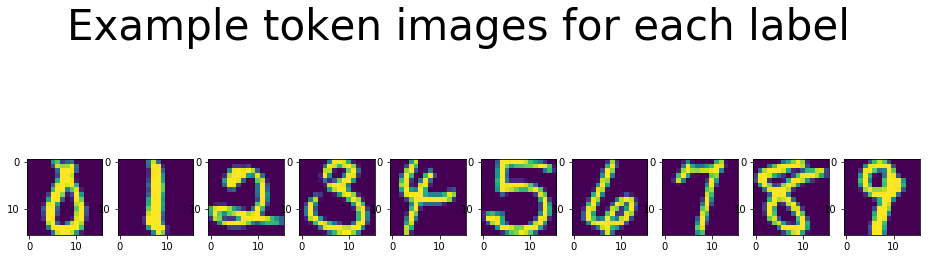

```python
idxs = [50, 71, 63, 31, 84, 120, 51, 26, 60, 87]
fig = plt.figure(figsize=(16, 16))
columns = 10
rows = 5
i = 0
for idx in idxs:
    i += 1
    im = X_train[idx-1,:]
    img = np.reshape(im, (16,16))
    fig.add_subplot(rows, columns, i)
    plt.imshow(img)
fig.suptitle('Example token images for each label', fontsize=42)

plt.show()
```

### Βήμα 4

Υπολογίζουμε τη μέση τιμή των χαρακτηριστικών του pixel (10, 10) για το ψηφίο «0» με βάση τα train δεδομένα. Το αποτέλεσμα είναι ένας αριθμός της τάξης του -0.93, δηλαδή μια πολύ μικρή τιμή δεδομένης της κλίμακας [-1,1]. Αυτό σημαίνει πως στη συγκεκριμένη θέση σπάνια βρίσκεται μέρος του σχεδίου του μηδέν, κάτι που είναι αναμενόμενο, μιας και η θέση αυτή είναι κεντρική και το σχήμα του μηδέν έχει κενό στο κέντρο. Σημειώνεται πως το offset στη γραμμή των πινάκων για ένα pixel (I,J) με τα (I,J) να ξεκινούν την αρίθμηση από 1 υπολογίζεται ως i$\cdot$16 + j. Χρησιμοποιήθηκε η συνιστώμενη τεχνική του vectorization.

```python
xzeros = X_train[Y_train==0]
np.mean(xzeros[:,9*16+9])
```

```
-0.9272646566164154
```

### Βήμα 5

Στη συνέχεια υπολογίζουμε τη διασπορά των τιμών για το ίδιο pixel στα ψηφία μηδέν και αυτή με vectorization. Η διαπορά βγαίνει 0.084 και επομένως η τυπική απόκλιση 0.29. Είναι στο εν τρίτο περίπου της ακτίνας του διαστήματος τιμών.

```python
xzeros = X_train[Y_train==0]
np.std(xzeros[:,9*16+9])**2
```

```
0.08392455977262078
```

### Βήμα 6

Υπολογίζουμε τα ίδια μεγέθη για όλα τα pixel των εικόνων του ψηφίου μηδέν. Για επαλήθευση τα εκτυπώνουμε για το pixel(10,10) και βγαίνουν ίδια με πριν όπως και έπρεπε.

```python
xzeros = X_train[Y_train==0]
avg = np.reshape(np.mean(xzeros, axis=0),(16,16))
print(avg[9][9])
dev = np.reshape(np.std(xzeros, axis=0),(16,16))
var = dev**2
print(var[9][9])
```

```
-0.927264656616415
0.08392455977261963
```

### Βήμα 7

Στο παρακάτω plot βλέπουμε την απεικόνιση της μέσης τιμής των pixels για το ψηφίο μηδέν. Η απεικόνιση αυτή έχει τη μορφή του ψηφίου αυτού και είναι πιο καθαρή σε σχέση με τα δείγματα (πιο συμμετρικο, πιο ομαλες καμπύλες, ενιαίο πάχος). Ωστόσο το πάχος έχει αυξηθεί (difusion) και οι τιμές των pixels έχουν μειωθεί στο εσωτερικό του σχήματος (λιγότερο κίρτινα σε σχέση με πριν).

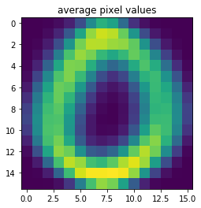

```python
plt.imshow(avg)
plt.show
plt.title('average pixel values')
```

### Βήμα 8

Η απεικόνιση που προκύπτει από τη διασπορά είναι πιο διεσταλμένη, αλλά έχει παρόμοια μορφή με αυτή της μέσης τιμής.Η διασπορά είναι μεγαλύτερη εκεί που οι τιμές των εικόνων είναι μεγαλύτερες, δηλαδή εκεί που υπάρχει σκίτσο, όπως και αναμέναμε.

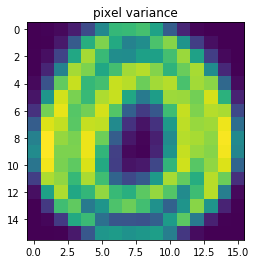

```python
plt.imshow(var)
plt.show
plt.title('pixel variance')
```

### Βήμα 9

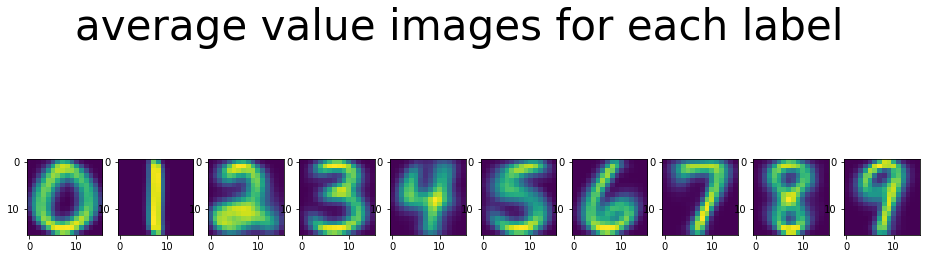

```python
avg = np.zeros((10,16,16))
avgq = np.zeros((10,16,16))
cnt = np.zeros((10,16,16))
for k in range(len(X_train)):
    for i in range(0,16):
        for j in range(0,16):
            cnt[int(Y_train[k])][i][j] += 1
            avg[int(Y_train[k])][i][j] += X_train[k][i*16 + j]
            avgq[int(Y_train[k])][i][j] += X_train[k][i*16 + j]**2
#element wise
avg = np.true_divide(avg, cnt)
avgq = np.true_divide(avgq, cnt)
var = avgq - np.multiply(avg, avg)

fig = plt.figure(figsize=(16, 16))
columns = 10
rows = 5
i = 0
for k in range(10):
    i += 1
    im = avg[k,:,:]
    img = np.reshape(im, (16,16))
    fig.add_subplot(rows, columns, i)
    plt.imshow(img)
fig.suptitle('average value images for each label', fontsize=42)

plt.show()
```

### Βήματα 10-11

Χρησιμοποποιούμε τις εικόνες με τις μέσες τιμές των pixels για κάθε label σαν κέντρα και αναθέτουμε σε κάθε εικόνα του test set το label του κέντρου από το οποίο απέχει λιγότερο με βάση την Ευκλείδια απόσταση των διανυσμάτων τους. Δηλαδή το label που ελαχιστοποιεί το τετραγωνικό άθροισμα των διαφορών των τιμών των αντίστοιχων pixel. Η μέθοδος αυτή είχε ποσοστό επιτυχίας 81.4% επί του συνολικού test set. Για παράδειγμα,η εκατοστή πρώτη εικόνα ταξινομήθηκε σωστά στα μηδενικά.

```python
classify=[]
for test in X_test:
    dist=[]
    for label in avg:
        dist.append(np.linalg.norm(np.reshape(label, 256)-test))
    classify.append(np.argmin(dist))

hits = sum(classify == Y_test)
total = len(Y_test)
print("hit rate equals", hits / total)

print('Image NO 101 was given label', classify[100])
print("It's real label is", int(Y_test[100]))
```

```
hit rate equals 0.8141504733432985
Image NO 101 was given label 0
It's real label is 0
```

### Βήμα 12 (Euclidean Classifier)

Υλοποιούμε τον ταξινομητή ευκλείδιας απόστασης σαν ένα scikit-learn estimator. Στη μέθοδο fit υπολογίζουμε τις μέσες τιμές όπως πριν με δεδομένο στα ορίσματα ένα train set. Στην predict αξιοποιούμε τον πίνακα με τις μέσες τιμές (κέντρα) που υπάρχει στην κλάση για για να υπολογίσουμε τα labels για ένα test set που δίνεται στα ορίσματα της μεθόδου.Η μέθοδος επιστρέφει ένα πίνακα με τα labels για καθεμία από τις γραμμές του test. Η μέθοδος score παίρνει ως όρισμα ένα test set χαρακτηριστικών καθώς και τα πραγματικά labels των στοιχείων, καλεί την predict δίνοντας της το συγκεκριμένο test set αι υπολογίζει το ποστό επιτυχίας ταξινόμησης. Ο ταξινομητής μπορεί να δεχτεί δεδομένα σε μορφή δισδιάσταων πινάκων με αυθαίρετο (αλλά φυσικά κοινό) πλήθος χαρακτηριστικών.

```python
from sklearn.base import BaseEstimator, ClassifierMixin
from sklearn.utils.validation import check_X_y, check_array, check_is_fitted
from sklearn.utils.multiclass import unique_labels
from sklearn.model_selection import learning_curve
import numpy as np

class EuclideanClassifier(BaseEstimator, ClassifierMixin):
    """Classify samples based on the Euclidean distance from the mean feature value"""

    def __init__(self, classes=None):
        # Χ_mean: numpy.ndarray of shape (n_classes, n_features)
        self.X_mean_ = None
        self.classes = None



    def fit(self, X, y):
        """
        This should fit classifier. All the "work" should be done here.

        Calculates self.X_mean_ based on the mean
        feature values in X for each class.

        self.X_mean_ becomes a numpy.ndarray of shape
        (n_classes, n_features)

        fit always returns self.
        """
        ## X: (n_training examples)x(n_features)
        ## y is an 1d vector: 1x(number of training examples)

        # Check that X and y have correct shape
        (X,y) = check_X_y(X, y)
        # Store the classes seen during fit
        self.classes = unique_labels(y)

        # Number of features
        (_, n_features) = X.shape
        # Initialization
        self.X_mean_ = np.zeros(( (len(self.classes)), n_features ))

        # Compute X_mean_
        for label in self.classes:
            label = int(label)
            labelX = X[y == label]
            labelX = np.mean(labelX, axis=0)
            self.X_mean_[label] = np.add(self.X_mean_[label], labelX)

        return self


    def predict(self, X):
        """
        Make predictions for X based on the
        euclidean distance from self.X_mean_
        """
        ## X: (n_tests)x(n_features)

        # Input validation
        X = check_array(X)

        # Initialize y_predict
        (n_tests, _) = X.shape
        y_predict = np.zeros((n_tests, 1))

        for test in range(len(X)):
            eucl_classify = []
            for train in self.X_mean_:
                # Euclidean distance

                eucl_classify.append( np.linalg.norm(train - X[test]) )
            # Predict the min euclidean distance for each test
            y_predict[test] = np.argmin(eucl_classify)

        return y_predict


    def score(self, X, y_truth):
        """
        Return accuracy score on the predictions
        for X based on ground truth y_truth
        """
        y_predict = self.predict(X)
        return ( np.sum([y_predict == y_truth]) ) / ( len(y_predict) )
```

### Βήμα 13(α) Euclidean Classifier Cross Validation Scoring

Θα χρησιμοποιήσουμε cross validation και θα βγάλουμε ποσοστά επιτυχίας για διαφορετικούς διαχωρισμούς των δεδομένων σε train και test. Συνενώνουμε τα test και train set που μας δίνονται σε ένα συνολικό διάνυσμα δεδομένων και κάθε φορά παίρνουμε διαφορετικό κομμάτι του συνολικού διανύσματος σαν train set. Πάνω σε αυτό εκπαιδεύουμε τον ταξινομητή και στη συνέχεια χρησιμοποιούμε τα υπόλοιπα δεδομένα σαν test. Αυτό το επαναλαμβάνουμε για 5 διαφορετικά σπασίματα των δεδομένων, βρίσκουμε κάθε φορά το ποσοστό επιτυχίας και τελικά παίρνουμε το μέσο όρο αυτών για να έχουμε κι ένα συνολικό ποσοστό. Με τη μέθοδο αυτή αξιοποιούμε καλύτερα τα διαθέσιμα δεδομένα για την εξαγωγή ενός αντιπροσωπευτικού ποσοστού επιτυχίας μιας και κάθε example χρησιμοποιείται τελικά και ως train στοιχείο και ως test. Φυσικά αυτοί οι 2 ρόλοι απαγορεύεται να συνυπάρξουν για ένα στοιχείο στην ίδια επανάληψη, γιατί νοθεύεται έτσι η διαδικασία πρόβλεψης.

```python
import warnings
warnings.filterwarnings("ignore",category=DeprecationWarning)
warnings.filterwarnings("ignore",category=FutureWarning)

import numpy as np
from sklearn.model_selection import KFold
from sklearn.model_selection import cross_val_score

# Read train.txt
# X_train, Y_train
train = []
with open("train.txt", 'r') as f:
    for line in f:
        line = line.split(" ")
        del line[-1]
        for i in range(0, len(line)):
            line[i] = float(line[i])
        train.append(line.copy())

train = np.asarray(train)

y_train = train[0:,0]
X_train = train[:,1:]

import numpy as np

# Read text.txt
# X_test, Y_test
with open('test.txt', 'r') as f:
    l = [[(num) for num in line.split(' ')] for line in f]
TEST = np.zeros( (len(l), len(l[0])-1) )
for i in range(len(l)):
    for j in range(len(l[0])-1):
        TEST[i][j]=float(l[i][j][:])
TEST[0:2][0:2589999]

X_test = TEST[:,1:]
Y_test = TEST[0:,0]

X = np.concatenate((X_train,X_test), axis=0)
y = np.concatenate((y_train,Y_test), axis=0)

# 5-Fold Cross Validation
scores = cross_val_score(EuclideanClassifier(), X, y,
                         cv=KFold(n_splits=5, random_state=32),
                         scoring="accuracy")
print('scores on each of the 5 splits: ',scores)
print("CV Average Score: " + str(np.mean(scores)))
```

```
scores on each of the 5 splits:  [0.85860215 0.83494624 0.84784946 0.84561592 0.81656805]
CV Average Score: 0.8407163638677286
```

### Βήμα 13(β) Περιοχές Απόφασης Ευκλείδιου Ταξινομητή

Στο σημείο αυτό θα προσπαθήσουμε να απεικονίσουμε τις περιοχές απόφασης του ταξινομητή. Για το σκοπό αυτό θα πρέπει να απομονώσουμε 2 χαρακτηριστικά που να καταφέρνουν όσο το δυνατόν καλύτερα να διαχωρίσουν τα δείγματα. Τα χαρακτηριστικά που δίνονται στο dataset είναι ξεχωριστά. Με τις τιμές 2 pixel μόνο δε μπορούμε να περιμένουμε καλά αποτελέσματα. Θα πρέπει να χρησιμοποιήσουμε καποιους συνδυασμούς των pixels ώστε να πάρουμε ένα κατάλληλο για το διαχωρισμό ενδιάμεσο embedding. Σε κάθε περίπτωση καλό είναι να κανονικοποιήσουμε τις τιμές των χαρακτηριστικών. Δοκιμάζουμε δύο διαφορετικά embeddings.

Το πρώτο είναι μια ευριστική απεικόνιση που γίνεται πάνω σε δύο χαρακτηριστικά του σκελετού των σκίτσων: το μήκος του σκελετού που υπολογίζεται ως το άθροισμα των pixels του (boolean τιμές) και ένα μέγεθος που εκφράζει τη διασπορά της "μάζας" του σκελετού γύρω από το κέντρο του και υπολογίζεται όπως η ροπή αδρανείας των φυσικών σωμάτων. Ο ταξινομητής καταφέρνει σε αυτό το embedding να ταξινομήσει τα δείγματα με ένα ποσοστό επιτυχίας 25%. Είναι καλύτερο από το εντελώς τυχαίο 10% αλλά πολύ χειρότερο από το 84% του ταξινομητή που αξιοποιεί και τα 256 χαρακτηριστικά.

Στο δεύτερο embedding απεικονίσαμε τα 256 χαρακτηριστικά σε 2 διαστάσεις εφαρμόζοντας pca. Ο ταξινομητής πέτυχε σε αυτή την περίπτωση ποσοστό 51%. Είναι εμφανώς χειρότερο από το ποσοστό όταν χρησιμοποιήθηκε πλήρης αριθμός χαρακτηριστικών, ωστόσο για 2 μόνο διαστάσεις είναι ένα ικανοποιητικό αποτέλεσμα.

Στα διαγράμματα των περιοχών απόφασης βλέπουμε με συνεχές χρώμα (contour) τις περιοχές απόφασης, δηλαδή για κάθε label το γεωμετρικό τόπο του x-y επιπέδου όπου ο ταξινομητής δεχόμενος την τούπλα [x,y] δίνει ως έξοδο το label αυτό. Επίσης βλέπουμε την απεικόνιση των δειγμάτων του train πάνω στο x-y επίπεδο (scatter). Κάθε σημείο του train πηγαίνει στην κατάλληλη θέση x,y ανάλογα με τις τιμές των χαρακτηριστικών του κι έχει το χρώμα που αντιστοιχεί στο label του. Όσο πιο ομαδοποιημένα είναι τα σημεία και όσο λιγότερο επικαλύπτεται η κάθε ομάδα με τις υπόλοιπες τόσο καλύτερο classification έχουμε πετύχει. Στην περίπτωση των χαρακτηριστικών του σκελετού οι ομάδες που δημιουργούνται έχουν μεγάλη επικάλυψη και γι'αυτό υπάρχει και υψηλό ποσοστό λάθους. Επίσης παρατηρούμε ότι τα δύο χαρακτηριστικά είναι σε κάποιο βαθμό συσχετισμένα με αποτέλεσμα τα σημεία να μην απλώνονται σε όλο το x-y επίπεδο, αλλά να είναι συγκεντρωμένα γύρω από μια ευθεία y=ax. Αντίθετα, στην περίπτωση του pca τα δείγματα κατανέμονται σε όλο το επίπεδο και δημιουργούνται ομάδες με μικρότερη επικάλυψη.

Επίσης τυπώνουμε τις τιμές των χαρακτηριστικών για κάθε κέντρο στην περίπτωση του σκελετού και του pca και βλέπουμε πόσο variance έχουν αυτά. Και στις 2 περιπτώσεις υπάρχει μεταβλητότητα από κέντρο σε κέντρο και στην περίπτωση του pca αυτή είναι μεγαλύτερη.

```python
import warnings
warnings.filterwarnings("ignore",category=DeprecationWarning)
warnings.filterwarnings("ignore",category=FutureWarning)

import numpy as np
import matplotlib.pyplot as plt

def plot_clf(clf, X, y, labels, plot_labels):
    # function that plots decision regions
    fig, ax = plt.subplots()
    # title for the plots
    title = ('Decision surface of Classifier')

    # Initializations
    # X0: Skeleton area
    # X1: Skeleton variance
    X0, X1 = X[:,0], X[:,1]

    x_min, x_max = X0.min() - 0.2, X0.max() + 0.2
    y_min, y_max = X1.min() - 0.2, X1.max() + 0.2
    xx, yy = np.meshgrid(np.arange(x_min, x_max, .05),
                         np.arange(y_min, y_max, .05))

    Z = clf.predict(np.c_[xx.ravel(), yy.ravel()])
    Z = Z.reshape(xx.shape)
    out = ax.contourf(xx, yy, Z, cmap=plt.cm.coolwarm, alpha=0.8)

    colors = ['red', 'yellow', 'blue', 'green', 'black', 'purple', 'orange', 'silver', 'grey', 'brown']

    for label in labels:
        ax.scatter(
            X0[y == label], X1[y == label],
            c=(colors[int(label)]), label=int(label),
            s=60, alpha=0.9, edgecolors='k'
        )

    ax.set_ylabel(plot_labels[1])
    ax.set_xlabel(plot_labels[0])
    ax.set_xticks(())
    ax.set_yticks(())
    ax.set_title(title)
    ax.legend()
    plt.show()
```

```python
import warnings
warnings.filterwarnings("ignore",category=DeprecationWarning)
warnings.filterwarnings("ignore",category=FutureWarning)

import numpy as np
import matplotlib.pyplot as plt

def znorm(x, axis=0):
    return (x - x.min(axis=axis)) / (x.max(axis=axis) - (x.min(axis=axis)))

# Descriptor 1: Skeleton Area
def area_skeleton(skeleton):
    # Area of the image skeleton
    area_skeleton = sum(sum(skeleton))

    return area_skeleton

# Descriptor 2: Skeleton Variance
def variance_skeleton(skeleton, area_skeleton):
    # Rx, Ry
    Ri = 0
    Rj = 0
    for i in range(16):
        for j in range(16):
            if (skeleton[i][j] == True):
                Ri += i
                Rj += j
    Ri /= area_skeleton
    Rj /= area_skeleton

    # Moment of Inertia, Angular Mass
    I = 0
    for i in range(16):
        for j in range(16):
            if (skeleton[i][j] == True):
                I += (Ri - i)**2 + (Rj - j)**2

    return I
```

```
feature values for each center:
[[0.51523575 0.45013227]
 [0.18880068 0.07921207]
 [0.36909509 0.28291601]
 [0.393326   0.34217179]
 [0.27835792 0.14145521]
 [0.41332466 0.35345816]
 [0.32075109 0.20279671]
 [0.27725548 0.19402933]
 [0.34898328 0.24784081]
 [0.27494384 0.15785788]]
scores on each of the 5 splits:  [0.24742975 0.27572016 0.2345679  0.22702332 0.24348422]
CV Average Score: 0.245645071365377
```

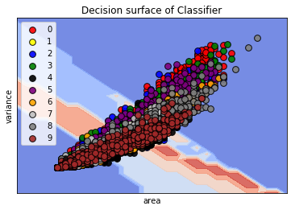

```python
X_tr = X_train[:,:]
y_tr = y_train[:]

# Initializations
# X0: Skeleton area
# X1: Skeleton variance
X0, X1 = np.zeros((len(X_tr), 1)), np.zeros((len(X_tr), 1))

from skimage.morphology import skeletonize

# Produce descriptor features for plot
for i in range(len(X_tr)):
    img = ((X_tr[i].reshape(16,16)) + np.ones((16,16))) / 2
    skeleton = skeletonize(img)
    X0[i] = area_skeleton(skeleton)
    X1[i] = variance_skeleton(skeleton, X0[i])

# Normalization and Concatenation
X = np.concatenate((znorm(X0), znorm(X1)), axis=1)

clf = EuclideanClassifier()
clf.fit(X, y_tr)
print('feature values for each center:')
print(clf.X_mean_)

# 5-Fold Cross Validation
scores = cross_val_score(EuclideanClassifier(), X, y_tr,
                         cv=KFold(n_splits=5, random_state=22),
                         scoring="accuracy")
print('scores on each of the 5 splits: ',scores)
print("CV Average Score: " + str(np.mean(scores)))


plot_clf(clf, X, y_tr, clf.classes, ["area", "variance"])
```

```
feature values for each center:
[[ 9.13878345 -1.97268522]
 [-7.99260998 -2.46554278]
 [ 1.05846674 -0.49165186]
 [ 1.47803408  0.61560111]
 [-2.20735064  2.33435672]
 [ 2.27891177 -0.7316747 ]
 [ 0.85914989 -5.29417789]
 [-2.82662208  7.26222408]
 [-1.70981281  0.5201006 ]
 [-3.53088211  3.44985132]]
scores on each of the 5 splits:  [0.50582591 0.56652949 0.5048011  0.47050754 0.49931413]
CV Average Score: 0.5093956343061514
```

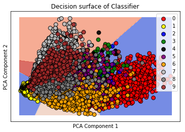

```python
import warnings
warnings.filterwarnings("ignore",category=DeprecationWarning)
warnings.filterwarnings("ignore",category=FutureWarning)

import pandas as pd
from sklearn.preprocessing import StandardScaler
from sklearn.decomposition import PCA

X_t = pd.DataFrame(data=X_train)
X_t = StandardScaler().fit_transform(X_t)
pca = PCA(n_components=2)
principalComponents = pca.fit_transform(X_t)

principalDf = pd.DataFrame(data = principalComponents
             , columns = ['principal component 1', 'principal component 2'])
X_tr = np.array(principalDf)
X = X_tr
'''
# Normalization and Concatenation
X0, X1 = (np.reshape(X_tr[:,0], (len(X_tr), 1))), (np.reshape(X_tr[:,1], (len(X_tr), 1)))
X = np.concatenate((znorm(X0), znorm(X1)), axis=1)
'''

# Euclidean Classifier
clf = EuclideanClassifier()
clf.fit(X, y_tr)

print('feature values for each center:')
print(clf.X_mean_)

# 5-Fold Cross Validation
scores = cross_val_score(EuclideanClassifier(), X, y_tr,
                         cv=KFold(n_splits=5, random_state=32),
                         scoring="accuracy")
print('scores on each of the 5 splits: ',scores)
print("CV Average Score: " + str(np.mean(scores)))

plot_clf(clf, X, y_tr, clf.classes, ["PCA Component 1", "PCA Component 2"])
```

### Βήμα 13(γ) Learning Curve

Τέλος κάνουμε plot το learning curve. To διάγραμμα αυτό μας δείχνει πως μεταβάλλεται το training score και το cross-validation score καθώς προσθέτουμε δείγματα στη μάθηση. Υψηλό training score δείχνει καλό fitting (lower bias), αν όμως αυτό συνοδεύεται με χαμηλό validation score σημαίνει πως υπάρχει υψηλό variance και overfitting. Θέλουμε να βρούμε μια καλή ισορροπία μεταξύ αυτών των παραμέτρων ώστε να επιτυγχάνονται καλά score και γενίκευση. Με τη βοήθεια αυτής της καμπύλης βλέπουμε πότε έχει νόημα να σταματήσουμε την εκπαίδευση λόγω κορεσμού (τα score συγκλίνουν σε συγκεκριμένες τιμές καθώς προσθέτουμε δείγματα). Επίσης βλέπουμε αν ο estimator πάσχει από bias error, οπότε τα μεγέθη συγκλίνουν σε κακές τιμές είτε variance error, οπότε το training score είναι πολύ ψηλότερο από το cross-validation score. Στην πρώτη περίπτωση έχει πρόβλημα το μοντέλο μας είτε η παραμετροποίησή του ενώ στη δεύτερη περιμένουμε ότι αύξηση του αριθμού των δειγμάτων μάθησης θα βελτίωνε την ικανότητα γενίκευσης.

Στο δικό μας παράδειγμα το training score πέφτει (ελαφρώς) και το validation score αυξάνει καθώς προσθέτουμε δείγματα ξεκινώντας από 1000, ενώ μετά τα 4000 δείγματα επέρχεται σύγκλιση. Ξεκινάμε την εκπαίδευση από ένα ποσοστό της τάξης του 10% των δειγμάτων και φροντίζουμε στο αρχικό ποσοστό να υπάρχουν δείγματα από όλες τις πιθανές κλάσεις. Αν θέλουμε να μην είναι υποχρεωτικό αυτό πρέπει να ξαναορίσουμε τον ταξινομητή ώστε να έχει προκαθορισμένες κλάσεις αντί να μαθαίνει δυναμικά ποιες είναι αυτές καθώς έρχονται νέα δείγματα. Το κάνουμε στο τέλος και αυτό για να έχουμε μια εικόνα του τι συμβαίνει για πολύ μικρό αριθμό δειγμάτων. Για μικρό αριθμό δειγμάτων το training score είναι πολύ υψηλό και το cross validation score πολύ χαμηλό.

```python
import warnings

from sklearn.model_selection import learning_curve
import numpy as np

X = np.concatenate((X_train,X_test), axis=0)
y = np.concatenate((y_train,Y_test), axis=0)

train_sizes, train_scores, test_scores = learning_curve(
    EuclideanClassifier(), X, y, cv=5, n_jobs=-1, scoring = "accuracy",
    train_sizes=np.linspace(0.11, 1.0, 5))
```

```
<module 'matplotlib.pyplot' from '/home/bill/.local/lib/python3.5/site-packages/matplotlib/pyplot.py'>
```

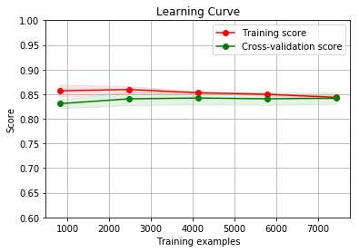

```python
import matplotlib.pyplot as plt

def plot_learning_curve(train_scores, test_scores, train_sizes, ylim=(0, 1)):
    plt.figure()
    plt.title("Learning Curve")
    if ylim is not None:
        plt.ylim(*ylim)
    plt.xlabel("Training examples")
    plt.ylabel("Score")



    train_scores_mean = np.mean(train_scores, axis=1)
    train_scores_std = np.std(train_scores, axis=1)
    test_scores_mean = np.mean(test_scores, axis=1)
    test_scores_std = np.std(test_scores, axis=1)
    plt.grid()

    plt.fill_between(train_sizes, train_scores_mean - train_scores_std,
                     train_scores_mean + train_scores_std, alpha=0.1,
                     color="r")
    plt.fill_between(train_sizes, test_scores_mean - test_scores_std,
                     test_scores_mean + test_scores_std, alpha=0.1, color="g")
    plt.plot(train_sizes, train_scores_mean, 'o-', color="r",
             label="Training score")
    plt.plot(train_sizes, test_scores_mean, 'o-', color="g",
             label="Cross-validation score")

    plt.legend(loc="best")
    return plt

plot_learning_curve(train_scores, test_scores, train_sizes, ylim=(.6, 1))
```

```
<module 'matplotlib.pyplot' from '/home/bill/.local/lib/python3.5/site-packages/matplotlib/pyplot.py'>
```

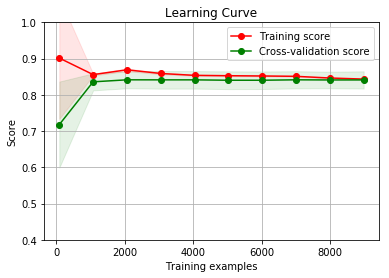

```python
from sklearn.base import BaseEstimator, ClassifierMixin
from sklearn.utils.validation import check_X_y, check_array, check_is_fitted
from sklearn.utils.multiclass import unique_labels
from sklearn.model_selection import learning_curve
import numpy as np


#redifining the euclidean estimator to have a predefined number of classes so that we can start from a low number of training samples for the learning curve


class EuclideanClassifier(BaseEstimator, ClassifierMixin):
    """Classify samples based on the Euclidean distance from the mean feature value"""

    def __init__(self, classes=None):
        # Χ_mean: numpy.ndarray of shape (n_classes, n_features)
        self.X_mean_ = None
        self.classes = None



    def fit(self, X, y):
        """
        This should fit classifier. All the "work" should be done here.

        Calculates self.X_mean_ based on the mean
        feature values in X for each class.

        self.X_mean_ becomes a numpy.ndarray of shape
        (n_classes, n_features)

        fit always returns self.
        """
        ## X: (n_training examples)x(n_features)
        ## y is an 1d vector: 1x(number of training examples)

        # Check that X and y have correct shape
        (X,y) = check_X_y(X, y)
        # Store the classes seen during fit
        self.classes =  np.linspace(0, 9, num=10)

        # Number of features
        (_, n_features) = X.shape
        # Initialization
        self.X_mean_ = np.zeros(( (len(self.classes)), n_features ))

        # Compute X_mean_
        for label in self.classes:
            label = int(label)
            labelX = X[y == label]
            labelX = np.mean(labelX, axis=0)
            self.X_mean_[label] = np.add(self.X_mean_[label], labelX)

        return self


    def predict(self, X):
        """
        Make predictions for X based on the
        euclidean distance from self.X_mean_
        """
        ## X: (n_tests)x(n_features)

        # Input validation
        X = check_array(X)

        # Initialize y_predict
        (n_tests, _) = X.shape
        y_predict = np.zeros((n_tests, 1))

        for test in range(len(X)):
            eucl_classify = []
            for train in self.X_mean_:
                # Euclidean distance

                eucl_classify.append( np.linalg.norm(train - X[test]) )
            # Predict the min euclidean distance for each test
            y_predict[test] = np.argmin(eucl_classify)

        return y_predict


    def score(self, X, y_truth):
        """
        Return accuracy score on the predictions
        for X based on ground truth y_truth
        """
        y_predict = self.predict(X)
        return ( np.sum([y_predict == y_truth]) ) / ( len(y_predict) )


train_sizes, train_scores, test_scores = learning_curve(
    EuclideanClassifier(), X, y, cv=30, n_jobs=-1, scoring = "accuracy",
    train_sizes=np.linspace(0.01, 1.0, 10))


plot_learning_curve(train_scores, test_scores, train_sizes, ylim=(0.4, 1))
```

### Βημα 14

Βρίσκουμε τις a priori πιθανότητες για κάθε κλάση/label που μπορεί ένα δείγμα να ταξινομηθεί, δηλαδή από το Y_train βρίσκουμε για κάθε κλάση c το $P(Y_c) = \dfrac {N_c}{N}$. Προφανώς, περιμένουμε το άθροισμα τους να ισούται με 1.

```python
# Find the a priori probalities for each class/label
labels = [([Y_train == label]) for label in unique_labels(Y_train)]
Y_train_size = len(Y_train)
a_priori = [(np.sum(label, axis=1) / Y_train_size)[0] for label in labels]
print(a_priori)

# Checked sum(a_priori = 1)
print(sum(a_priori))
```

```
[0.16376354409546015, 0.13784117405019888, 0.10026059525442327, 0.09024825126868742, 0.08942531888629818, 0.07625840076807022, 0.09107118365107666, 0.08846523110684405, 0.07433822520916199, 0.08832807570977919]
1.0
```

### Βήμα 15) Bayesian Classifier

H βασική ιδέα λειτουργίας του ταξινομητή είναι α) ο γνωστός νόμος του Bayes $$P(A\mid B)={\frac {P(B\mid A)\,P(A)}{P(B)}}$$  και β) η (naive) υπόθεση ότι τα χαρακτηριστικά είναι όλα ανεξάρτητα μεταξύ τους (στην περίπτωσή μας τα χαρακτηριστικά είναι τα pixel των εικόνων και για τα γειτονικά pixel δεν ισχύει η υπόθεση της ανεξαρτησίας).  Με δεδομένα μια μεταβλητή κατηγορίας (κλάσης) $y$ και ένα εξαρτώμενο διάνυσμα χαρακτηριστικών $x_1$ μέχρι $x_n$, σύμφωνα με το θεώρημα του Bayes θα ισχύει $$P(y \mid x_1, \dots, x_n) = \frac{P(y) P(x_1, \dots x_n \mid y)}{P(x_1, \dots, x_n)}$$ Ισχύει ότι $P(x_1, \dots, x_i, \dots, x_n \mid y) = \prod_{i=1}^{n} P(x_i | y, x_1, \dots, x_{i-1}, x_{i+1}, \dots, x_n)$ και κάνουμε την αφελή υπόθεση ότι το χαρακτηριστικό $x_i$ για κάθε $i$ εξαρτάται μόνο από τo label $y$ και όχι από οποιοδήποτε άλλο χαρακτηριστικό $$P(x_i | y, x_1, \dots, x_{i-1}, x_{i+1}, \dots, x_n) = P(x_i | y)$$ αυτό οδηγεί στην απλοποίηση $$P(y \mid x_1, \dots, x_n) = \frac{P(y) \prod_{i=1}^{n} P(x_i \mid y)}{P(x_1, \dots, x_n)}$$ Με δεδομένη είσοδο, το $P(x_1, \dots, x_n)$ είναι σταθερό. Συνεπώς μπορούμε να χρησιμοποιήσουμε τον ακόλουθο κανόνα ταξινόμησης $$P(y \mid x_1, \dots, x_n) \propto P(y) \prod_{i=1}^{n} P(x_i \mid y)$$ $$\Downarrow$$ $$\hat{y} = \arg\max_y P(y) \prod_{i=1}^{n} P(x_i \mid y)\quad (1) $$ Το $P(y)$ είναι η υπόθεσή μας και ισούται με τη σχετική συχνότητα του label $y$ στο training set. To $P(x_i \mid y)$ είναι η πιθανοφάνεια δηλαδή η πιθανότητα του δείγματος με δεδομένη την υπόθεσή μας και μπορεί επίσης να υπολογιστεί απλά από το training set. Οι διάφοροι Naive Bayes classifiers διαφοροποιούνται κυρίως από τις υποθέσεις που κάνουν ως προς την κατανομή $P(x_i \mid y)$. Το label $\hat{y}$ που ανατίθεται σε ένα νέο δείγμα είναι αυτή που μεγιστοποιεί το δεξί μέλος της σχέσης.  Στην περίπτωσή μας τα χαρακτηριστικά (τιμές pixels) παίρνουν συνεχείς τιμές. Θα δουλέψουμε λοιπόν με τις πυκνότητες πιθανότητας των χαρακτηριστικών: $$P(x_i \mid y) = \frac{1}{\sqrt{2\pi\sigma^2_y}} \exp\left(-\frac{(x_i - \mu_y)^2}{2\sigma^2_y}\right)$$ και τις apriori πιθανότητες των labels, εφαρμόζοντας τον ίδιο τύπο.  Υλοποιούμε τον Bayesian Classifier σαν έναν scikit-learn εκτιμητή. Ο εκτιμητής αυτός υπολογίζει στη μέθοδο fit τις δεσμευμένες κατανομές των χαρακτηριστικών δεδομένου του κάθε label και τις a priori κατανομές των labels. Γίνεται η υπόθεση πως οι κατανομές των χαρακτηριστικών είναι κανονικές. Έτσι η κάθε κατανομή προσδιορίζεται πλήρως από τη μέση τιμή και τη διασπορά της. Η μέση τιμή και η διασπορά παίρνουν ως τιμές τις πειραματικές (στατιστικές) τιμές τους με βάση τα δείγματα του train. Επειδή η διασπορά υπάρχει στον παρονομαστή της συνάρτησης πυκνότητας μηδενισμοί της διασποράς θα οδηγήσουν σε απροσδιοριστίες. Για να το αποφύγουμε αυτό προσθέτουμε σε όλες τις αποκλίσεις ένα κοινό μικρό offset της τάξης του 10^-6.

Στην predict υπολογίζονται οι δεσμευμένες πιθανότητες των labels, δεδομένων των χαρακτηριστικών του test sample και επιλέγεται αυτό με τη μεγαλύτερη πιθανότητα, όπως ορίζει ο τύπος (1). Ισοδύναμα μπορούμε να επιλέξουμε το label που έχει τη μεγαλύτερη λογαριθμική πιθανοφάνεια, δηλαδή να πάρουμε το λογάριθμο της έκφρασης (1): $$\hat{y} = \arg\max_y \{log(P(y))+ \sum_{i=1}^{n} log(P(x_i \mid y))\} \quad=\quad \arg\max_y \{ log(P(y))+ \sum_{i=1}^{n} log(\frac{1}{\sqrt{2\pi\sigma^2_y}})+ \sum_{i=1}^{n}\left(-\frac{(x_i - \mu_y)^2}{2\sigma^2_y}\right)\}$$ Ο μετασχηματισμός αυτός βολεύει γιατί πλέον υπολογίζουμε αθροίσματα αντί για γινόμενα και έχουμε μεγαλύτερη αριθμητική ευστάθεια. Στην υλοποίησή μας έχουμε δουλέψει με λογαρίθμους python:log (φυσικός λογάριθμος).

Η score δουλεύει επιστρέφει το accuracy της πρόβλεψης για ένα test set που δέχεται ως όρισμα.

```python
class BayesianClassifier(BaseEstimator, ClassifierMixin):
    # Bayesian Classifier
    def __init__(self):
        # Χ_mean: numpy.ndarray of shape (n_classes, n_features)
        self.a_priori = None
        n_labels = None
        n_features = None
        var = None
        sigma = None
        avg = None

    def fit(self, X, y):
        self.n_labels = len(unique_labels(y))
        self.n_features = X.shape[1]

        # Find a priori probabilities
        labels = [([y == label]) for label in unique_labels(y)]
        y_train_size = len(y)
        self.a_priori = [(np.sum(label, axis=1) / y_train_size)[0] for label in labels]

        # Find mean,var for each class/label
        self.avg = np.zeros((self.n_labels, self.n_features))
        avgq = np.zeros((self.n_labels, self.n_features))
        cnt = np.zeros((self.n_labels, self.n_features))
        for k in range(len(X)):
            for i in range(self.n_features):
                cnt[int(y[k])][i] += 1
                self.avg[int(y[k])][i] += X[k][i]
                avgq[int(y[k])][i] += X[k][i]**2
        # μ
        self.avg = np.true_divide(self.avg, cnt)
        avgq = np.true_divide(avgq, cnt)
        # σ^2, σ
        self.var = avgq - (self.avg)**2
        self.sigma = (self.var)**0.5

        return self


    def predict(self, X):
        # Bayes Classifier predict on given test data
        # return [np.argmin( (np.sum(np.log(self.sigma + 0.0001), axis=1) + np.sum(np.true_divide((X[i] - self.avg)**2, self.var + 0.0001), axis=1)) - np.log(self.a_priori) ) for i in len(X)]
        y_predict = np.zeros(len(X))
        i = 0
        log_a_priori = np.log(self.a_priori)
        for x in X:
            expPart = np.true_divide((x - self.avg)**2, self.var + 10**(-6))
            sumPart = np.sum(expPart, axis=1)
            varPart = np.sum(np.log(self.sigma + 10**(-6)), axis=1)
            res = (varPart + sumPart) - log_a_priori
            y_predict[i] = np.argmin(res)
            i += 1

        return y_predict


    def score(self, X, y_truth):
        y_predict = self.predict(X)

        return ( np.sum([y_predict == y_truth]) ) / ( len(y_predict) )


    def predict_proba(self, X):
        # Returns probability estimates for the test vector X.
        prob_predict = np.zeros(len(X), n_labels)
        i = 0
        log_a_priori = np.log(self.a_priori)
        for x in X:
            expPart = np.true_divide((x - self.avg)**2, self.var + 0.0001)
            sumPart = np.sum(expPart, axis=1)
            varPart = np.sum(np.log(self.sigma + 0.0001), axis=1)
            res = (varPart + sumPart) - log_a_priori
            prob_predict[i] = res
            i += 1

        return prob_predict
```

### Βήμα 15(α)

Εφαρμόζουμε τον εκτιμητή στο test set και παίρνουμε τα προβλεπόμενα labels

```python
clf = BayesianClassifier()
clf.fit(X_train, Y_train)
y_predict = clf.predict(X_test)
print(y_predict)
```

```
[9. 6. 3. ... 4. 0. 1.]
```

### Βήμα 15(β) NBGaussian CV Scoring:

Μελετάμε την επίδοση του ταξινομητή με cross-validation. Τα αποτελέσματα είναι ελαφρώς χειρότερα από τον mean euclidean. Παρατηρώντας τον τύπο του bayesian βλέπουμε ότι είναι γενίκευση του mean euclidean, λαμβάνοντας υπόψιν και διασπορές και τις apriori πιθανότητες. Αν οι διασπορές και οι apriori πιθανότητες είναι ίδιες για όλες τα χαρακτηριστικά και τις κλάσεις, τότε οι δύο ταξινομητές δουλεύουν με τον ίδιο τρόπο. Η επιδείνωση οφείλεται πιθανά στην υπόθεση των κατανομών των pixels που κάναμε και τελικά δεν ισχύουν (ανεξάρτητες κανονικές).

```python
print("Current Score: " + str(clf.score(X_test, Y_test)))
# 5-Fold Cross Validation
scores = cross_val_score(BayesianClassifier(), X, y,
                         cv=KFold(n_splits=5, random_state=32),
                         scoring="accuracy")
print('NBGaussian Classifier scores on each of the 5 splits: ',scores)
print("NBGaussian CV Average Score: " + str(np.mean(scores)))
```

```
Current Score: 0.763328350772297
NBGaussian Classifier scores on each of the 5 splits:  [0.81612903 0.7983871  0.75591398 0.79397526 0.76331361]
NBGaussian CV Average Score: 0.7855437945016108
```

### Βήμα 15(γ) Sklearn implementation of NBGaussian CV Average Score:

Συγκρίνουμε την υλοποίησή μας με τον έτοιμο Naive Bayes του sklearn. Ο έτοιμος βγάζει χειρότερα αποτελέσματα κατά 5 ποσοστιαίες μονάδες. Είναι μια ανεκτή απόκλιση που οφείλεται στο διαφορετικό τρόπο που διαχειρίζονται τους μηδενισμούς διασπορών και γενικότερα στις διαφορετικές υλοποιήσεις.

```python
from sklearn.naive_bayes import GaussianNB

# 5-Fold Cross Validation
scores = cross_val_score(GaussianNB(), X, y,
                         cv=KFold(n_splits=5, random_state=32),
                         scoring="accuracy")
print('sklearn NBGaussian scores on each of the 5 splits: ',scores)
print("sklearn NBGaussian CV Average Score: " + str(np.mean(scores)))
```

```
sklearn NBGaussian scores on each of the 5 splits:  [0.77956989 0.75806452 0.69892473 0.7380312  0.71382464]
sklearn NBGaussian CV Average Score: 0.7376829952512335
```

### Βήμα 16) NBGaussian with var=1:

Επαναλαμβάνουμε το 15(α) με $var = 1$

```python
clf = BayesianClassifier()
clf.fit(X_train, Y_train)
clf.var = np.ones((clf.n_labels, clf.n_features))
clf.sigma = np.ones((clf.n_labels, clf.n_features))
y_predict = clf.predict(X_test)
print(y_predict)
```

```
[9. 2. 3. ... 4. 0. 1.]
```

Επαναλαμβάνουμε το 15(β) με $var = 1$ Τα αποτελέσματα βελτιώθηκαν και είναι παρόμοια με τον mean euclidean. Τώρα ο NBGaussian ταξινομητής λειτουργεί όμοια με τον mean euclidean, με τη διαφορά ότι αφαιρεί από το κόστος το λογάριθμο των apriori.

```python
print("Current Score: " + str(clf.score(X_test, Y_test)))
```

```
Current Score: 0.8131539611360239
```

### Βήμα 17) KNN and SVM estimators

```python
from sklearn.neighbors import KNeighborsClassifier
from sklearn.metrics import accuracy_score

# k=1 (High Variance)
knn = KNeighborsClassifier(n_neighbors=1)
knn.fit(X_train, Y_train)
y_predict = knn.predict(X_test)
print("KNN Score:")
print(accuracy_score(Y_test, y_predict))
```

```
KNN Score:
0.9436970602889886
```

Στη συνέχεια πειραματιζόμαστε με ταξινομητή SVM και κάνουμε tuning της παραμέτρου C και του πυρήνα. Η ρύθμιση των υπερπαραμέτρων γίνεται με gridsearch. Η παράμετρος C είναι το αντίστροφο της σταθεράς regularization λ της συνάρτησης κόστους. Το λ προσπαθεί να αυξήσει το εύρος του κενού μεταξύ των διαχωριζόμενων κλάσεων και να μειώσει έτσι το variance. Το C πολλαπλασιάζεται με το misprediction loss και προσπαθεί έτσι να μειώσει το bias. Έτσι, μεγάλο C σημαίνει έμφαση στο fitting.

Ο πυρήνας είναι μια συνάρτηση που δίνει το εσωτερικό γινόμενο των μετασχηματισμών δύο διανυσμάτων στο χώρο απεικόνισης που δουλεύουμε. Η ιδέα αυτού του μετασχηματισμού είναι να αυξήσουμε τις διαστάσεις και να απεικονίσουμε τα διανύσματα χαρακτηριστικών στον χώρο αυτό, όπου οι περιοχές των κλάσεων είναι γραμμικά διαχωρίσιμες (διαχωρίζονται με hyperplane). Έστω φ η συνάρτηση απεικόνισης. Για το learning του ταξινομητή svm μας ενδιαφέρει ουσιαστικά η τιμή του εσωτερικού γινομένου των φ 2 διανυσμάτων: K(xi, xj)=dot(φ(xi), φ(xj)), δηλαδή το Κ (kernel) χωρίς να χρειαζόμαστε τη συνάρτηση απεικόνισης φ (kernel trick). Στη περίπτωση του linear kernel αναζητούμε γραμμικό διαχωρισμό των κλάσεων.

Ο πολυωνυμικός kernel είναι η συνάρτηση K(xi,xj)=(dot(xi,xj)+1)^p

Ο σιγμοειδής kernel είναι η συνάρτηση K(xi,xj)=tanh(ηdot(xi,xj)+v)

Ο rbf kernel είναι η συνάρτηση K(xi,xj)=exp(-γ(xi-xj)^2)

Για τον SVM μελετήσαμε διαφορετικούς τύπους (linear, rbf, polynomial, sigmoid) με κλιμακώμενες τιμές για το C (1, 10, 100, 1000), καθώς και για την παράμετρο gamma για τον rbf SVM, και είδαμε ότι τα καλύτερα σκορ τα παρήγαγε ο polynomial svm (περίπου 98% accuracy με cross-validation), ένω πολύ υψηλά σκορ έδωσε και ο linear SVM (περίπου 95% accuracy με cross-validation), γεγονός που σημαίνει ότι το πρόβλημα ήταν και γραμμικώς επιλύσιμο από τον SVM.

```python
from sklearn.model_selection import train_test_split
from sklearn.model_selection import GridSearchCV
from sklearn.metrics import classification_report
from sklearn.svm import SVC

# Set the parameters by cross-validation
tuned_parameters = [{'kernel': ['rbf'], 'gamma': [1e-3, 1e-4],
                     'C': [1, 10, 100, 1000]},
                    {'kernel': ['linear'], 'C': [1, 10, 100, 1000]},
                   {'kernel': ['sigmoid'], 'C': [1, 10, 100, 1000]},
                   {'kernel': ['poly'], 'C': [1, 10, 100, 1000]}]

scores = ['accuracy']

for score in scores:
    print("# Tuning hyper-parameters for %s" % score)
    print()

    # GridSearchCV
    clf = GridSearchCV(SVC(), tuned_parameters, cv=5,
                       scoring=score)
    clf.fit(X_train, Y_train)

    print("Best parameters set found on development set:")
    print()
    print(clf.best_params_)
    print()
    print("Grid scores on development set:")
    print()
    means = clf.cv_results_['mean_test_score']
    stds = clf.cv_results_['std_test_score']
    for mean, std, params in zip(means, stds, clf.cv_results_['params']):
        print("%0.3f (+/-%0.03f) for %r"
              % (mean, std * 2, params))
    print()

    print("Detailed classification report:")
    print()
    print("The model is trained on the full development set.")
    print("The scores are computed on the full evaluation set.")
    print()
    y_true, y_predict = Y_test, clf.predict(X_test)
    print(classification_report(y_true, y_predict))
    print()
```

```
# Tuning hyper-parameters for accuracy

Best parameters set found on development set:

{'C': 10, 'kernel': 'poly'}

Grid scores on development set:

0.955 (+/-0.007) for {'gamma': 0.001, 'C': 1, 'kernel': 'rbf'}
0.913 (+/-0.015) for {'gamma': 0.0001, 'C': 1, 'kernel': 'rbf'}
0.968 (+/-0.007) for {'gamma': 0.001, 'C': 10, 'kernel': 'rbf'}
0.953 (+/-0.006) for {'gamma': 0.0001, 'C': 10, 'kernel': 'rbf'}
0.968 (+/-0.011) for {'gamma': 0.001, 'C': 100, 'kernel': 'rbf'}
0.963 (+/-0.010) for {'gamma': 0.0001, 'C': 100, 'kernel': 'rbf'}
0.968 (+/-0.011) for {'gamma': 0.001, 'C': 1000, 'kernel': 'rbf'}
0.959 (+/-0.009) for {'gamma': 0.0001, 'C': 1000, 'kernel': 'rbf'}
0.955 (+/-0.010) for {'C': 1, 'kernel': 'linear'}
0.955 (+/-0.010) for {'C': 10, 'kernel': 'linear'}
0.955 (+/-0.010) for {'C': 100, 'kernel': 'linear'}
0.955 (+/-0.010) for {'C': 1000, 'kernel': 'linear'}
0.943 (+/-0.007) for {'C': 1, 'kernel': 'sigmoid'}
0.929 (+/-0.015) for {'C': 10, 'kernel': 'sigmoid'}
0.895 (+/-0.020) for {'C': 100, 'kernel': 'sigmoid'}
0.886 (+/-0.022) for {'C': 1000, 'kernel': 'sigmoid'}
0.974 (+/-0.003) for {'C': 1, 'kernel': 'poly'}
0.981 (+/-0.006) for {'C': 10, 'kernel': 'poly'}
0.980 (+/-0.007) for {'C': 100, 'kernel': 'poly'}
0.980 (+/-0.007) for {'C': 1000, 'kernel': 'poly'}

Detailed classification report:

The model is trained on the full development set.
The scores are computed on the full evaluation set.

              precision    recall  f1-score   support

         0.0       0.98      0.99      0.98       359
         1.0       1.00      0.97      0.98       264
         2.0       0.94      0.94      0.94       198
         3.0       0.95      0.91      0.93       166
         4.0       0.90      0.94      0.92       200
         5.0       0.93      0.94      0.93       160
         6.0       0.96      0.96      0.96       170
         7.0       0.99      0.93      0.96       147
         8.0       0.91      0.94      0.93       166
         9.0       0.95      0.97      0.96       177

    accuracy                           0.95      2007
   macro avg       0.95      0.95      0.95      2007
weighted avg       0.95      0.95      0.95      2007
```

Αρα, **SVM > KNN > Euclidean Classifier > Bayesian Classifier**

### Βήμα 18(α) ensembling

Στο βήμα αυτό χρησιμοποιείται η τεχνική ensembling, δηλαδή ο συνδυασμός ταξινομητών με αρκετά καλή επίδοση με στόχο να επιτευχθεί επίδοση υψηλότερη των επιμέρους επιδόσεων, με τον κάθε ταξινομητή να εκπαιδεύεται σε όλο το training set. Είναι σημαντικό οι ταξινομητές που θα συνδυαστούν να χαρακτηρίζονται από διαφορετικό τύπο λαθών, προκειμένου να επιτευχθεί μια μικρή βελτίωση του score, η οποία βέβαια θα είναι αρκετά ασήμαντη σε σχέση με το υπολογιστικό κόστος(χρειάζεται ένας σχετικά μεγάλος αριθμός ταξινομητών στο συνολικό συνδυασμό προκειμένου να αποσβένονται τα τυχαία λάθη που κάνει ο κάθε επί μέρους).Συνδυάζουμε επτά ταξινομητές που έχουμε δει στα παραπάνω ερωτήματα, τους Polynomial SVM με C=10,100,1000, τον knn με κ=1,5 και τον rbf SVM με gamma=0.001 και C=100,1000. Θέτουμε για κάθε SVM το probability=True προκειμένου να επιστρέφει για κάθε sample τις επιμέρους πιθανότητες αυτό να ανηκεί σε κάθεμια κλάση και όχι το μόνο τον άσσο για την πιο πιθανή κλάση και 0 για τις λιγότερο πιθανές.

Χρησιμοποιούμε τον VotingClassifier σε δύο modes: hard και soft. Στον hard επιλέγεται με μορφή tournament η κλάση που πιστεύει η πλειοψηφία των classifiers και για αυτό το λόγο και επιλέγουμε μονό αριθμό classifiers προκειμένου να αποφευχθεί η πιθανότητα ισοπαλίας, καθώς οι ταξινομητές συνήθως δυσκολεύονται να αποφασίσουν μεταξύ δύο μόνο υποψήφιων κλάσεων από τις συνολικές. Από την άλλη, στο soft mode κάθε ταξινομητής παράγει τις πιθανότητες για κάθε sample αυτό να ανηκεί σε κάθε κλάση, συγκεκριμένα στην άσκησή μας για κάθε sample παράγονται 10 πιθανότητες για κάθε digit (0-9). Στην συνέχεια, για κάθε κλάση προστίθενται οι επιμέρους πιθανότητες όλων των ταξινομητών (έμβαρα) και επιλέγεται η κλάση με το μεγαλύτερο άθροισμα. Αρχικά, για το soft mode επιλέξαμε για βάρος κάθε ταξινομητή το accuracy score του, πάνω στο ίδιο training και test set που χρησιμοποιούμε και στον VotingClassifier, και είδαμε πως το accuracy score με ensembling δεν βελτίωνε αισθητά το καλύτερο score από τους επιμέρους ταξινομητές. Έτσι, αφήσαμε την default επιλογή και είδαμε πως το παραγομένο score με soft ensembling ήταν κατά 0.3% καλύτερο από το καλύτερο επιμέρους score των ταξινομητών. Στον hard η ακρίβεια ήταν όσο του καλύτερου από τον συνδυασμό, οπότε η τεχνική δεν επέφερε κάποια βελτίωση. Μόνο ο soft επέφερε βελτίωση.

```python
from sklearn.ensemble import VotingClassifier
from sklearn.svm import SVC
from sklearn.neighbors import KNeighborsClassifier
from sklearn.naive_bayes import GaussianNB
from sklearn.metrics import accuracy_score

clf1 = SVC(C=10, kernel='poly', probability=True)     # 95.31 %
clf2 = SVC(C=100, kernel='poly', probability=True)    # 95.27 %
clf3 = SVC(C=1000, kernel='poly', probability=True)   # 95.27 %
clf4 = KNeighborsClassifier(n_neighbors=1)
clf5 = KNeighborsClassifier(n_neighbors=5)
clf6 = SVC(C=100, gamma=0.001, kernel='rbf', probability=True)
clf7 = SVC(C=1000, gamma=0.001, kernel='rbf', probability=True)

clf1.fit(X_train, Y_train)
y_pre1 = clf1.predict(X_test)
acc_score1 = accuracy_score(Y_test, y_pre1)
print("clf1 accuracy score: " + str(acc_score1))

clf2.fit(X_train, Y_train)
y_pre2 = clf2.predict(X_test)
acc_score2 = accuracy_score(Y_test, y_pre2)
print("clf2 accuracy score: " + str(acc_score2))

clf3.fit(X_train, Y_train)
y_pre3 = clf3.predict(X_test)
acc_score3 = accuracy_score(Y_test, y_pre3)
print("clf3 accuracy score: " + str(acc_score3))

clf4.fit(X_train, Y_train)
y_pre4 = clf4.predict(X_test)
acc_score4 = accuracy_score(Y_test, y_pre4)
print("clf4 accuracy score: " + str(acc_score4))

clf5.fit(X_train, Y_train)
y_pre5 = clf5.predict(X_test)
acc_score5 = accuracy_score(Y_test, y_pre5)
print("clf5 accuracy score: " + str(acc_score5))

clf6.fit(X_train, Y_train)
y_pre6 = clf6.predict(X_test)
acc_score6 = accuracy_score(Y_test, y_pre6)
print("clf6 accuracy score: " + str(acc_score6))

clf7.fit(X_train, Y_train)
y_pre7 = clf7.predict(X_test)
acc_score7 = accuracy_score(Y_test, y_pre7)
print("clf7 accuracy score: " + str(acc_score7))

print()


# Hard VotingClassifier
eclf1 = VotingClassifier(estimators=[
    ('svm1', clf1), ('svm2', clf2), ('svm3', clf3), ('knn', clf4), ('knn2', clf5), ('svm4', clf6), ('svm5', clf7)],
        voting='hard')
eclf1 = eclf1.fit(X_train, Y_train)

y_predict = eclf1.predict(X_test)
print("Hard VotingClassifier score: " + str(accuracy_score(Y_test, y_predict)))

# Soft VotingClassifier
eclf2 = VotingClassifier(estimators=[
    ('svm1', clf1), ('svm2', clf2), ('svm3', clf3), ('knn', clf4), ('knn2', clf5), ('svm4', clf6), ('svm5', clf7)],
        voting='soft')
eclf2 = eclf2.fit(X_train, Y_train)

y_predict = eclf2.predict(X_test)
print("Soft VotingClassifier score: " + str(accuracy_score(Y_test, y_predict)))
```

[output not shown]

### Βήμα 18(β) bagging

Στο παρακάτω ερώτημα γίνεται χρήση της τεχνικής bagging που αφορά στο χωρισμό του training dataset σε τυχαία υποσύνολα, με πιθανές επικαλύψεις και την εφαρμογή ενός ταξινομητή σε κάθε ένα από αυτά. Η τελική απόφαση βγαίνει μέσω ψηφοφορίας ή μέσου όρου των προβλέψεων των επιμέρους ταξινομητών. To bagging είναι κατάλληλο για ασταθείς ταξινομητές, δηλαδή όταν διαφορετικά tests μπορεί να δώσουν έντονα διαφορετικές απαντήσεις, και σκοπεύουν να χαμηλώσουν το variance. Ωστοσό, στην άσκησή μας έχουμε το αντίθετο, δηλαδή με χρήση του bagging παίρνουμε high variance αφού οι ταξινομητές μας είναι αρκετά σταθεροί.

```python
from sklearn.ensemble import BaggingClassifier

# BaggingClassifier -- KNN
bagging = BaggingClassifier(base_estimator = KNeighborsClassifier(n_neighbors=1),
                          n_estimators = 7,
                          random_state = 32)

bagging.fit(X_train, Y_train)
y_predict_train = bagging.predict(X_train)
print("Train Bagging score: " + str(accuracy_score(Y_train, y_predict_train)))
y_predict = bagging.predict(X_test)
print("Test Bagging score: " + str(accuracy_score(Y_test, y_predict)))
```

```
Train Bagging score: 0.996708270470443
Test Bagging score: 0.9436970602889886
```

```python
from sklearn.ensemble import BaggingClassifier
from sklearn.svm import SVC

# BaggingClassifier -- SVM
bagging = BaggingClassifier(base_estimator = SVC(C=1000, kernel='poly', probability=True),
                          n_estimators = 2,
                          random_state = 32)

bagging.fit(X_train, Y_train)
y_predict_train = bagging.predict(X_train)
print("Train Bagging score: " + str(accuracy_score(Y_train, y_predict_train)))
y_predict = bagging.predict(X_test)
print("Test Bagging score: " + str(accuracy_score(Y_test, y_predict)))
```

```
Train Bagging score: 0.9965711150733781
Test Bagging score: 0.9516691579471849
```

```python
from sklearn.ensemble import BaggingClassifier
from sklearn.tree import DecisionTreeClassifier

# BaggingClassifier -- Random Forest
bagging = BaggingClassifier(base_estimator = DecisionTreeClassifier(),
                          n_estimators = 7,
                          random_state = 32)

bagging.fit(X_train, Y_train)
y_predict_train = bagging.predict(X_train)
print("Train Bagging score: " + str(accuracy_score(Y_train, y_predict_train)))
y_predict = bagging.predict(X_test)
print("Test Bagging score: " + str(accuracy_score(Y_test, y_predict)))
```

```
Train Bagging score: 0.996708270470443
Test Bagging score: 0.874439461883408
```

### Βήμα 19 (extra) (a) dataloader

Ένα από τα προβλήματα που προκύπτουν στο learning είναι πώς θα διαχειριζόμαστε το μεγάλο όγκο δεδομένων. Συγκεκριμένα, μπορεί ο όγκος να είναι τέτοιος ώστε να μην χωράνε όλα ταυτόχρονα στη RAM. Έτσι, πρέπει να αξιοποιήσουμε μεθόδους για να φορτώνουμε αποδοτικά τα δεδομένα κατά τη διαρκεία του training, αλλά και του testing, ώστε η διαδικασία του dataloading να μην αποτελέσει bottleneck για το συνολικό learning. Οι dataloaders φορτώνουν τα data σε batches, δηλαδή σε κομμάτια μη επικαλυπτόμενα του αρχικου dataset και μάλιστα αυτά μπορούν να δημιουργηθούν με παράλληλο τρόπο από το σύστημα (num workers). Στο παρακάτω μέρος, θα χρησιμοποιήσουμε neural networks, στην εκπαίδευση των οποίων γίνεται τροφοδότηση του δικτύου με batches και όχι με το κάθε sample χωριστά. Για αυτό το λόγο, θα χρησιμοποιήσουμε Dataloaders για την τροφοδότηση των data. Επιπλέον, αξίζει να τονιστεί ότι ένας άλλος λόγος χρήσης του dataloader είναι η λειτουργία του shuffling, που στοχεύει στην ανάμειξη των αρχικών data και άρα στην ομογενοποίησή τους. Ο dataloader που χρησιμοποιούμε προέρχεται από την βιβλιοθήκη της Pytorch, ενώ το dataset που δημιουργούμε (και στο οποίο εφαρμόζεται ο dataloader) κληρονομεί απο το dataset της pytorch. Στα πλαίσια της εφαρμογής μας, ο όγκος των δεδομένων είναι μικρός και έτσι δεν χρειάζεται να φορτώνουμε από τον δίσκο, αλλά από έναν πίνακα στην RAM. Έτσι, το indexing, που υλοποιήσαμε, δεν είναι indexing σε αρχεία, αλλά σε καταχωρήσεις πίνακα.

```python
import numpy as np

def readRawText(text):
    # Argument text: string of dataset filename
    with open(text, 'r') as f:
        l = [[(num) for num in line.split(' ')] for line in f]
    DATA = np.zeros( (len(l), len(l[0])-1) )
    for i in range(len(l)):
        for j in range(len(l[0])-1):
            DATA[i][j]=float(l[i][j][:])
    return DATA
```

```python
from torch.utils.data import Dataset, DataLoader
from torchvision import transforms, utils
import pandas as pd
import torch

class DigitDataset(Dataset):
    """Digit Recognition Dataset."""

    def __init__(self, data_file, transform=None):
        """
        Args:
            data_file: filename of the first data file
            transform (callable, optional): Optional transform to be applied
                on a sample.
        """
        self.dataset = readRawText(data_file)
        self.transform = transform


    # Return the number of samples
    def __len__(self):
        return len(self.dataset)


    # Get the sample with index equal to idx
    def __getitem__(self, idx):
        if torch.is_tensor(idx):
            idx = idx.tolist()

        sample = np.array(self.dataset[idx])

        if self.transform:
            sample = self.transform(sample)

        return sample[1:], sample[0]
```

```python
from torch.utils.data import Dataset, DataLoader

Train_dataset = DigitDataset("train.txt")
Test_dataset = DigitDataset("test.txt")

train_loader = DataLoader(Train_dataset, batch_size=100,
                    shuffle=True, num_workers=4)
test_loader = DataLoader(Test_dataset, batch_size=100,
                    shuffle=True, num_workers=4)
```

### Βήμα 19 (extra) (β) Pytorch NN

Θα υλοποιήσουμε ένα feed-forward Fully-connected Neural Network για να λύσουμε το πρόβλημα της ταξινόμησης των digits(0-9) που εξετάσαμε και παραπάνω. Θα χρησιμοποιησούμε την βιβλιοθήκη pytorch που μας προσφέρει μεγάλη ευελιξία στον σχεδιασμό του δικτύου μας και φθάνει σε ένα σχετικό βάθος της υλοποίησης. Συγκεριμένα, μας προσφέρει τους tensors και Variables που μπορούν να αναπαραστήσουν multi-diamensional arrays και δεν διαθέτουν τον χαρακτήρα απλών προγραμματιστικών μεταβλητών αλλά μαθηματικών μεταβλητών που μπορούμε να εφαρμόσουμε μεθόδους backward() που μελετούν το ιστορικό των μεταβολών τους και επιτρέπουν την εφαρμογή του backpropagation.

Επίσης, διαθέτουν μεθόδους που υλοποιούν ένα ενδιάμεσο layer του neural network, παίρνοντας μια πολυδιάστατη είσοδο και βγάζοντας μια πολυδιάστατη έξοδο. Κάθε στοιχείο της εξόδου του επιπέδου προκύπτει συνδυάζοντας τις εισόδους μεταξύ τους (εσωτερικό γινόμενο με τα αντίστοιχα βάρη) και περνώντας το αποτέλεσμα από μια συνάρτηση ενεργοποίησης. Έχουμε τη δυνατότητα να ρυθμίσουμε το πλήθος των επιπέδων, το μέγεθος του input και του output κάθε επιπέδου και τη συνάρτηση ενεργοποίησης του κάθε επιπέδου. Η διαδικασία του learning συνίσταται στην εκμάθηση των συναρτήσεων κάθε επιπέδου, δηλαδή στη διαμόρφωση των βαρών.

Το learning γίνεται κάνοντας για κάθε batch forward propagation και με βάση την έξοδο του δικτύου και το προκύπτον loss criterion backpropagation. Η διαδικασία τροφοδότησης του δικτύου με τα batches γίνεται επαναλητικά, οπότε αφότουν ολοκληρωθεί ένας κύκλος κατά τον οποίο έχουν περάσει όλα τα batches από το δίκτυο (εποχή) ξεκινάει ένας επόμενος όπου συμβαίνει το ίδιο και η διαδικασία επαναλαμβάνεται για ένα συγκεκριμένο αριθμό εποχών που δίνουμε στον ορισμό του μοντέλου. Το loss είναι επίσης στην ευχέρειά μα ςνα το ρυθμίσουμε για κάθε επίπεδο.

Στην έξοδο του νευρωνικού (σε μια εφαργμογή classification σαν τη δική μας) παίρνουμε μια τιμή για κάθε label που εκφράζει την πιθανότητα το sample εισόδου να έχει το συγκεκριμένο label και αποδίδουμε στο δείγμα το label που εχει τη μεγαλύτερη τιμή.

Στο παράδειγμά μας υλοποιούμε μια αρχιτεκτονική με σειριακά hidden layers (fully connected layers). Η είσοδος του νευρωνικού είναι ένα διάνυσμα αναπαράστασης μιας εικόνας (256 διαστάσεις) και η έξοδος είναι διάστασης 10, όσα και τα πιθανά labels της εισόδου. Η διάσταση εξόδου κάθε μη τελικού layer ταυτίζεται με τη διάσταση της εισόδου του επόμενου επιπέδου του pipeline. Πειραματιστήκαμε με διαφορετικά πλήθη κρυφών επιπέδων και διαφορετικά μεγέθη αυτών. Πειραματιζόμαστε επίσης με το learning rate και το πλήθος των εποχών. Αν το learning rate είναι υπερβολικά μεγάλο το δίκτυο δε θα μπορέσει να φτάσει με gradient descent στο ελάχιστο, καθώς τα βήματα θα είναι μεγάλα και θα ταλαντώνεται στην περιοχή του ελαχίστου. Επιπλέον θα παραβιάζεται η αρχή του gradient descent, ότι δηλαδή η μερική παράγβγος του κόστους ώς προις την κάθε ακμή είναι αρνητική, γιατί με μεγάλο learning rate οι μεταβολές των βαρών είναι μεγάλες και δεν προσεγγίζουν καλά τα διαφορικά dw και τις συνεχείς παραγώγους.Έτσι μπορεί τελικά το κόστος να αυξάνεται και το learning να αποκλίνει. Αυτό παρατηρήσαμε για μεγάλα rl, πχ 1. Από την άλλη αν έχουμε μικρό lr μπορεί να εγκλοβιστούμε σε τοπικά ελάχιστα ή να κατεβαίνουμε αργά προς το ολικό, οπότε να μην προλάβουμε εντός των καθορισμένων εποχών να φτάσουμε. Στη δεύτερη περίπτωση θα πρέπει να βάλουμε μεγάλο αριθμό εποχών, ενώ στην πρώτη μια λύση είναι να έχουμε μεγάλο lr στις πρώτες εποχές και στη συνέχεια να το μειώνουμε. Στα πλαίσια της παρούσας εργασίας έχουμε υποθέσει σταθερό lr οπότε αυτό που κάνουμε είναι να έχουμε μικρό lr και τον απαιτούμενο αριθμό εποχών.

Σε ό,τι αφορά τις συναρτήσεις ενεργοποίησης επιλέχθηκε στο τελικό στάδιο η logarithmic softmax, όπως συνηθίζεται σε προβλήματα classification. Η συνάρτηση αυτή, όπως λέει και το όνομά της είναι η soft εκδοχή του argmax που θα εφαρμόζαμε για να επιλέξουμε το prediction label. Αντί να αναθέτει 1 σε ένα label και 0 σε όλα τα υπόλοιπα υπολογίζει πιθανότητες για κάθε label (έχει αυστηρά θετικές τιμές, αθροιστικά για όλα τα label 1). Η log softmax λογαριθμίζει το αποτέλεσμα του softmax για σκοπούς αριθμητικής ευστάθειας, αλλά και για να "τιμωρεί" πιο αυστηρά τα λάθη πρόβλεψης, σε συνδυασμό βέβαια πάντα με τη losss funtion, την οποία εδώ δεν έχουμε ρυθμίσει, αλλά έχουμε αφήσει default υλοποίηση. Στα ενδιάμεσα στάδια πειραματιστήκαμε με sigmoid και relu, αλλά καταλήξαμε στη relu (γραμμική ενεργοποίηση) λόγω καλύτερων αποτελεσμάτων και ταχύτερης εκμάθησης.

```python
import torch
import torch.nn as nn
import torch.nn.functional as F

# Fully-connected Neural Network
class Net(nn.Module):
    def __init__(self):
        super(Net, self).__init__()
        self.fc1 = nn.Linear(256, 400)
        self.fc2 = nn.Linear(400, 100)
        self.fc3 = nn.Linear(100, 50)
        self.fc4 = nn.Linear(50, 10)

    def forward(self, x):
        x = F.relu(self.fc1(x))
        x = F.relu(self.fc2(x))
        x = F.relu(self.fc3(x))
        x = self.fc4(x)
        return F.log_softmax(x)
```

```python
import torch
import torch.nn as nn
import torch.nn.functional as F
from torch.autograd import Variable

net = Net()
#net.cuda()
print(net)

# create a stochastic gradient descent optimizer
optimizer = torch.optim.SGD(net.parameters(), lr=0.05, momentum=0.9)
# create a loss function
criterion = nn.NLLLoss()
# run the main training loop
epochs = 10
log_interval = 10
for epoch in range(epochs):
    for batch_idx, (data, target) in enumerate(train_loader):
        data, target = Variable(data), Variable(target)
        # resize data from (batch_size, 1, 28, 28) to (batch_size, 16*16)
        data = data.float()
        target = target.long()
        data = data.view(-1, 16*16)
        optimizer.zero_grad()
        net_out = net(data)
        loss = criterion(net_out, target)
        loss.backward()
        optimizer.step()
        if batch_idx % log_interval == 0:
            print('Train Epoch: {} [{}/{} ({:.0f}%)]\tLoss: {:.6f}'.format(
                    epoch, batch_idx * len(data), len(train_loader.dataset),
                           100. * batch_idx / len(train_loader), loss.item()))


# run tests
test_loss = 0
correct = 0
for data, target in test_loader:
    data = data.float()
    target = target.long()
    data, target = Variable(data, volatile=True), Variable(target)
    data = data.view(-1, 16 * 16)
    net_out = net(data)
    # sum up batch loss
    test_loss += criterion(net_out, target).item()
    pred = net_out.data.max(1)[1]  # get the index of the max log-probability
    correct += pred.eq(target.data).sum()

#     if (pred.eq(target.data) == 0):
#         plt.imshow(data.reshape(16.16))

test_loss /= len(test_loader.dataset)
print('\nTest set: Average loss: {:.4f}, Accuracy: {}/{} ({:.0f}%)\n'.format(
        test_loss, correct, len(test_loader.dataset),
        100. * correct / len(test_loader.dataset)))
```

```
Net(
  (fc1): Linear(in_features=256, out_features=400, bias=True)
  (fc2): Linear(in_features=400, out_features=100, bias=True)
  (fc3): Linear(in_features=100, out_features=50, bias=True)
  (fc4): Linear(in_features=50, out_features=10, bias=True)
)
Train Epoch: 0 [0/7291 (0%)]	Loss: 2.305232
Train Epoch: 0 [1000/7291 (14%)]	Loss: 2.198688
Train Epoch: 0 [2000/7291 (27%)]	Loss: 1.698539
Train Epoch: 0 [3000/7291 (41%)]	Loss: 0.849919
Train Epoch: 0 [4000/7291 (55%)]	Loss: 0.525318
Train Epoch: 0 [5000/7291 (68%)]	Loss: 0.553914
Train Epoch: 0 [6000/7291 (82%)]	Loss: 0.454217
Train Epoch: 0 [7000/7291 (96%)]	Loss: 0.325302
Train Epoch: 1 [0/7291 (0%)]	Loss: 0.209630
Train Epoch: 1 [1000/7291 (14%)]	Loss: 0.108581
Train Epoch: 1 [2000/7291 (27%)]	Loss: 0.189294
Train Epoch: 1 [3000/7291 (41%)]	Loss: 0.116094
Train Epoch: 1 [4000/7291 (55%)]	Loss: 0.270558
Train Epoch: 1 [5000/7291 (68%)]	Loss: 0.157097
Train Epoch: 1 [6000/7291 (82%)]	Loss: 0.099563
Train Epoch: 1 [7000/7291 (96%)]	Loss: 0.137680
Train Epoch: 2 [0/7291 (0%)]	Loss: 0.098385
Train Epoch: 2 [1000/7291 (14%)]	Loss: 0.276634
Train Epoch: 2 [2000/7291 (27%)]	Loss: 0.179465
Train Epoch: 2 [3000/7291 (41%)]	Loss: 0.071304
Train Epoch: 2 [4000/7291 (55%)]	Loss: 0.115539
Train Epoch: 2 [5000/7291 (68%)]	Loss: 0.152048
Train Epoch: 2 [6000/7291 (82%)]	Loss: 0.096766
Train Epoch: 2 [7000/7291 (96%)]	Loss: 0.137449
Train Epoch: 3 [0/7291 (0%)]	Loss: 0.065563
Train Epoch: 3 [1000/7291 (14%)]	Loss: 0.024598
Train Epoch: 3 [2000/7291 (27%)]	Loss: 0.058077
Train Epoch: 3 [3000/7291 (41%)]	Loss: 0.157525
Train Epoch: 3 [4000/7291 (55%)]	Loss: 0.076878
Train Epoch: 3 [5000/7291 (68%)]	Loss: 0.092598
Train Epoch: 3 [6000/7291 (82%)]	Loss: 0.247576
Train Epoch: 3 [7000/7291 (96%)]	Loss: 0.102422
Train Epoch: 4 [0/7291 (0%)]	Loss: 0.068195
Train Epoch: 4 [1000/7291 (14%)]	Loss: 0.044566
```

[output cut: 33 more lines]

```
Train Epoch: 8 [3000/7291 (41%)]	Loss: 0.008920
Train Epoch: 8 [4000/7291 (55%)]	Loss: 0.003104
Train Epoch: 8 [5000/7291 (68%)]	Loss: 0.071633
Train Epoch: 8 [6000/7291 (82%)]	Loss: 0.012048
Train Epoch: 8 [7000/7291 (96%)]	Loss: 0.076703
Train Epoch: 9 [0/7291 (0%)]	Loss: 0.003152
Train Epoch: 9 [1000/7291 (14%)]	Loss: 0.002441
Train Epoch: 9 [2000/7291 (27%)]	Loss: 0.058405
Train Epoch: 9 [3000/7291 (41%)]	Loss: 0.006795
Train Epoch: 9 [4000/7291 (55%)]	Loss: 0.033142
Train Epoch: 9 [5000/7291 (68%)]	Loss: 0.015721
Train Epoch: 9 [6000/7291 (82%)]	Loss: 0.013448
Train Epoch: 9 [7000/7291 (96%)]	Loss: 0.006884

Test set: Average loss: 0.3549, Accuracy: 1878/2007 (94%)
```

Βλέπουμε ότι καθώς προχωράει το learning (περνάνε οι εποχές) το loss μειώνεται (όχι απαραίτητα γνησίως).

```python
from torch.utils.data import Dataset, DataLoader

Test_dataset = DigitDataset("test.txt")

test_loader = DataLoader(Test_dataset, batch_size=1,
                    shuffle=True, num_workers=4)
```

```
Predicted label probabilities for the first ten mispredicted images:


mispredicted image 1 label probabilities:
[(0, '-13.33'), (1, '-11.81'), (2, '-14.97'), (3, '-29.02'), (4, '-12.69'), (5, '-10.82'), (6, '-0.00'), (7, '-19.91'), (8, '-12.28'), (9, '-22.00')]
predicted label= 6 correct label= 1

mispredicted image 2 label probabilities:
[(0, '-32.19'), (1, '-3.12'), (2, '-0.05'), (3, '-20.89'), (4, '-12.90'), (5, '-10.60'), (6, '-6.91'), (7, '-15.42'), (8, '-12.03'), (9, '-31.25')]
predicted label= 2 correct label= 6

mispredicted image 3 label probabilities:
[(0, '-14.21'), (1, '-17.25'), (2, '-2.65'), (3, '-9.70'), (4, '-21.92'), (5, '-16.82'), (6, '-11.27'), (7, '-12.81'), (8, '-0.07'), (9, '-23.10')]
predicted label= 8 correct label= 2

mispredicted image 4 label probabilities:
[(0, '-19.59'), (1, '-12.05'), (2, '-19.61'), (3, '-1.99'), (4, '-7.77'), (5, '-0.97'), (6, '-20.66'), (7, '-13.36'), (8, '-1.36'), (9, '-1.49')]
predicted label= 5 correct label= 3

mispredicted image 5 label probabilities:
[(0, '-18.61'), (1, '-17.39'), (2, '-11.71'), (3, '-0.00'), (4, '-22.31'), (5, '-7.45'), (6, '-22.18'), (7, '-17.44'), (8, '-7.44'), (9, '-21.81')]
predicted label= 3 correct label= 5

mispredicted image 6 label probabilities:
[(0, '-14.29'), (1, '-7.65'), (2, '-12.11'), (3, '-0.41'), (4, '-9.22'), (5, '-2.00'), (6, '-15.25'), (7, '-9.63'), (8, '-1.65'), (9, '-4.87')]
predicted label= 3 correct label= 5

mispredicted image 7 label probabilities:
[(0, '-10.02'), (1, '-9.14'), (2, '-4.64'), (3, '-5.78'), (4, '-0.05'), (5, '-5.15'), (6, '-8.83'), (7, '-3.72'), (8, '-7.37'), (9, '-5.14')]
predicted label= 4 correct label= 9

mispredicted image 8 label probabilities:
[(0, '-14.22'), (1, '-8.70'), (2, '-11.77'), (3, '-11.11'), (4, '-0.83'), (5, '-7.55'), (6, '-9.90'), (7, '-4.03'), (8, '-7.26'), (9, '-0.60')]
predicted label= 9 correct label= 4

mispredicted image 9 label probabilities:
[(0, '-0.96'), (1, '-14.71'), (2, '-4.53'), (3, '-0.54'), (4, '-14.16'), (5, '-3.75'), (6, '-9.58'), (7, '-9.86'), (8, '-5.51'), (9, '-14.53')]
predicted label= 3 correct label= 8

mispredicted image 10 label probabilities:
[(0, '-11.24'), (1, '-10.28'), (2, '-13.95'), (3, '-10.34'), (4, '-2.86'), (5, '-0.92'), (6, '-8.25'), (7, '-12.79'), (8, '-0.61'), (9, '-6.48')]
predicted label= 8 correct label= 3



fisrt 60 mispredicted images:
```

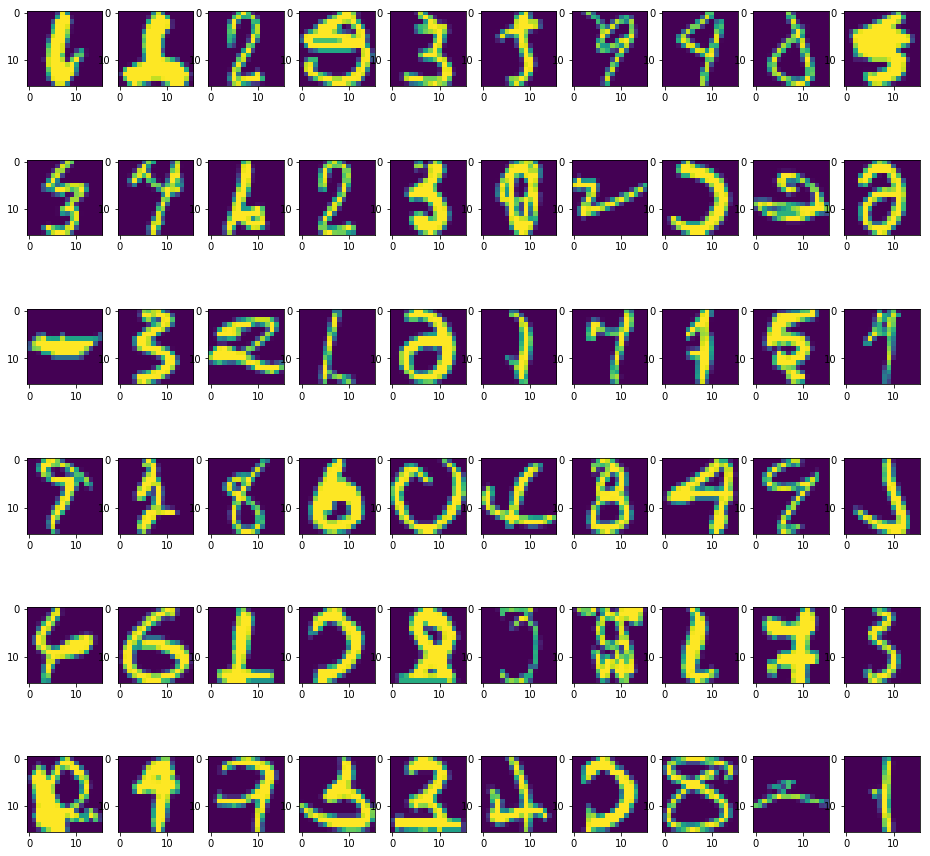

```
Test set: Average loss: 0.3467, Accuracy: 1882/2007 (94%)
```

```python
import matplotlib.pyplot as plt
import warnings
warnings.filterwarnings("ignore",category=UserWarning)

print('\nPredicted label probabilities for the first ten mispredicted images:\n\n')

# run tests
test_loss = 0
correct = 0
columns = 10
rows = 6
i = 1
flag=1
fig = plt.figure(figsize=(16, 16))
for data, target in test_loader:
    data = data.float()
    target = target.long()
    data, target = Variable(data, volatile=True), Variable(target)
    data = data.view(-1, 16 * 16)
    net_out = net(data)
    # sum up batch loss
    test_loss += criterion(net_out, target).item()
    pred = net_out.data.max(1)[1]  # get the index of the max log-probability
    correct += pred.eq(target.data).sum()

    # Plot some misclassified digits
    if (flag==1)and(pred.eq(target.data).sum() == 0):
        if i<11:
            print('mispredicted image {} label probabilities:'.format(i))
            print( list(enumerate(["{0:.2f}".format(x) for x in np.asarray(net_out.data.tolist()).squeeze()])) )
            print('predicted label=',pred.tolist()[0],'correct label=', target.data.tolist()[0],'\n')
        fig.add_subplot(rows, columns, i)
        plt.imshow(np.reshape(data,(16,16)))
        i += 1
        if(i == 61):
            flag=0

print('\n\nfisrt 60 mispredicted images:\n\n')
plt.show()

test_loss /= len(test_loader.dataset)
print('\nTest set: Average loss: {:.4f}, Accuracy: {}/{} ({:.0f}%)\n'.format(
        test_loss, correct, len(test_loader.dataset),
        100. * correct / len(test_loader.dataset)))
```

Με πειράματα που κάναμε καταλήξαμε στον παρακάτω πίνακα αποτελεσμάτων:

Πίνακας: Αξιολόγηση επίδοσης Neural Network

| Activation Functions | Learning Rate | Epochs | Pipeline | Accuracy Score |
| --- | --- | --- | --- | --- |
| relu-relu-log_softmax | 0.005 | 200 | 256-200-200-10 | 94 |
| relu-relu-log_softmax | 0.005 | 50 | 256-200-200-10 | 94 |
| relu-relu-log_softmax | 0.005 | 50 | 256-200-200-10 | 94 |
| relu-relu-log_softmax | 0.005 | 30 | 256-400-100-10 | 94 |
| relu-log_softmax | 0.005 | 30 | 256-400-10 | 94 |
| sigmoid-sigmoid-log_softmax | 0.005 | 30 | 256-400-100-10 | 88 |
| relu-relu-relu-log_softmax | 0.005 | 30 | 256-400-100-50-10 | 93 |
| logsigmoid-logsigmoid-logsigmoid-log_softmax | 0.005 | 30 | 256-400-100-50-10 | 91 |
| logsigmoid-logsigmoid-logsigmoid-log_softmax | 0.05 | 30 | 256-400-100-50-10 | 93 |
| relu-relu-relu-log_softmax | 0.05 | 50 | 256-400-100-50-10 | 94 |
| relu-relu-relu-log_softmax | 0.05 | 100 | 256-400-100-50-10 | 94 |

### Βήμα 19γ) PYTORCH NN AS AN SKLEARNER

```python
import torch
import torch.nn as nn
import torch.nn.functional as F
from torch.autograd import Variable
from torch.utils.data import Dataset, DataLoader
from sklearn.base import BaseEstimator, ClassifierMixin
from sklearn.utils.validation import check_X_y, check_array, check_is_fitted
from sklearn.utils.multiclass import unique_labels
from sklearn.model_selection import learning_curve
import numpy as np

class ScikitDataset(Dataset):
    """Dataset for scikit-learn package use."""
    def __init__(self, dataset, transform=None):
        """
        Args:
            data_file: np.array of dataset
            transform (callable, optional): Optional transform to be applied
            on a sample.
        """
        self.dataset = dataset
        self.transform = transform

    def __len__(self):
        # Return the number of samples
        return len(self.dataset)

    def __getitem__(self, idx):
        # Get the sample with index equal to idx
        if torch.is_tensor(idx):
            idx = idx.tolist()
        sample = np.array(self.dataset[idx])
        if self.transform:
            sample = self.transform(sample)
        return sample[1:], sample[0]


class ScikitDataset_test(Dataset):
    """Dataset for scikit-learn package use."""
    def __init__(self, dataset, transform=None):
        """
        Args:
            data_file: np.array of dataset
            transform (callable, optional): Optional transform to be applied
            on a sample.
        """
        self.dataset = dataset
        self.transform = transform

    def __len__(self):
        # Return the number of samples
        return len(self.dataset)

    def __getitem__(self, idx):
        # Get the sample with index equal to idx
        if torch.is_tensor(idx):
            idx = idx.tolist()
        sample = np.array(self.dataset[idx])
        if self.transform:
            sample = self.transform(sample)
        return sample


class Net(nn.Module):
    def __init__(self, layers_size, activation_functions):
        self.activation_functions = activation_functions
        super(Net, self).__init__()
        self.fc0 = 0
        self.fc1 = 0
        self.fc2 = 0
        self.fc3 = 0
        self.fc4 = 0
        self.fc5 = 0
        self.fc6 = 0
        self.fc7 = 0
        self.fc8 = 0
        self.fc9 = 0
        for i in range(len(layers_size)-1):
            if (i == 0):
                self.fc0 = nn.Linear(layers_size[i], layers_size[i+1])
            elif (i == 1):
                self.fc1 = nn.Linear(layers_size[i], layers_size[i+1])
            elif (i == 2):
                self.fc2 = nn.Linear(layers_size[i], layers_size[i+1])
            elif (i == 3):
                self.fc3 = nn.Linear(layers_size[i], layers_size[i+1])
            elif (i == 4):
                self.fc4 = nn.Linear(layers_size[i], layers_size[i+1])
            elif (i == 5):
                self.fc5 = nn.Linear(layers_size[i], layers_size[i+1])
            elif (i == 6):
                self.fc6 = nn.Linear(layers_size[i], layers_size[i+1])
            elif (i == 7):
                self.fc7 = nn.Linear(layers_size[i], layers_size[i+1])
            elif (i == 8):
                self.fc8 = nn.Linear(layers_size[i], layers_size[i+1])


    def forward(self, x):
        i = 0
        for af in self.activation_functions:
            if (i == 0):
                x = af(self.fc0(x))
            elif (i == 1):
                x = af(self.fc1(x))
            elif (i == 2):
                x = af(self.fc2(x))
            elif (i == 3):
                x = af(self.fc3(x))
            elif (i == 4):
                x = af(self.fc4(x))
            elif (i == 5):
                x = af(self.fc5(x))
            elif (i == 6):
                x = af(self.fc6(x))
            elif (i == 7):
                x = af(self.fc7(x))
            elif (i == 8):
                x = af(self.fc8(x))
            elif (i == 9):
                x = af(self.fc9(x))
            i += 1

        return x


class NeuralNetwork(BaseEstimator, ClassifierMixin):
    # Fully-connected Neural Network compatible with sklearn
    def __init__(self, n_features, n_classes, layers_size=[10,10,10], n_layers=2, lr=0.05, epochs=10):
        '''
            n_features:    number of features
            n_classes:     number of classes
            layers_size:   list of layers sizes
            n_layers:      number of layers (hidden and output)
        '''
        self.net = None
        self.n_layers = n_layers
        self.layers_size = layers_size
        self.activation_functions = []
        self.n_features = n_features
        self.n_classes = n_classes
        self.lr = lr
        self.criterion = None
        self.optimizer = None
        self.epochs = epochs
        # relu - relu -...- log_softmax activation functions
        for layer in range(n_layers-1):
            relu = lambda x : F.relu(x)
            self.activation_functions.append(relu)
        log_softmax = lambda x : F.log_softmax(x)
        self.activation_functions.append(log_softmax)


    def fit(self, X, y):
        # Training
        dataAll = np.c_[y, X]
        # DataLoader
        dataset = ScikitDataset(dataAll)
        train_loader = DataLoader(dataset, batch_size=100,
                    shuffle=False, num_workers=4)

        # Neural Network
        self.net = Net(self.layers_size, self.activation_functions)
        #print(self.net)

        # create a stochastic gradient descent optimizer
        self.optimizer = torch.optim.SGD(self.net.parameters(), lr=self.lr, momentum=0.9)
        # create a loss function
        self.criterion = nn.NLLLoss()
        # run the main training loop
        log_interval = self.epochs / 4
        for epoch in range(self.epochs):
            for batch_idx, (data, target) in enumerate(train_loader):
                data, target = Variable(data), Variable(target)
                data = data.float()
                target = target.long()
                data = data.view(-1, self.n_features)
                self.optimizer.zero_grad()
                net_out = self.net(data)
                loss = self.criterion(net_out, target)
                loss.backward()
                self.optimizer.step()
#                 if batch_idx % log_interval == 0:
#                      print('Train Epoch: {} [{}/{} ({:.0f}%)]\tLoss: {:.6f}'.format(
#                              epoch, batch_idx * len(data), len(train_loader.dataset),
#                                     100. * batch_idx / len(train_loader), loss.item()))
        return self


    def predict(self, X):
        dataset = ScikitDataset_test(X)
        test_loader = DataLoader(dataset, batch_size=1,
                    shuffle=False, num_workers=4)

        y_predict = []
        for data in test_loader:
            data = data.float()
            data = Variable(data, volatile=True)
            data = data.view(-1, self.n_features)
            net_out = self.net(data)
            y_predict.append(net_out.data.max(1)[1].item())  # get the index of the max log-probability

        return y_predict


    def score(self, X, y_truth):
        y_predict = self.predict(X)
        return ( np.sum([y_predict == y_truth]) ) / ( len(y_predict) )
```

```python
net = NeuralNetwork(256, 10, [256,400,100,50,10], 4)
net.fit(X_train, Y_train)
print(net.score(X_test, Y_test))
```

```
0.9382162431489786
```

### Βήμα 19δ GRIDSEARCH FOR NN PARAMETERS

```python
from sklearn.model_selection import train_test_split
from sklearn.model_selection import GridSearchCV
from sklearn.metrics import classification_report

# Set the parameters by cross-validation
tuned_parameters = [{'lr': [0.5], 'epochs': [10], 'n_layers': [3], 'layers_size': [[256, 200, 120, 10]]},
                    {'lr': [0.05], 'epochs': [10], 'n_layers': [2], 'layers_size': [[256, 350, 10]]},
                    {'lr': [0.05], 'epochs': [30], 'n_layers': [3], 'layers_size': [[256, 250, 180, 10]]},
                    {'lr': [0.005], 'epochs': [100], 'n_layers': [3], 'layers_size': [[256, 100, 20, 10]]}]

scores = ['accuracy']

for score in scores:
    print("# Tuning hyper-parameters for %s" % score)
    print()

    # GridSearchCV
    clf = GridSearchCV(NeuralNetwork(n_features=256, n_classes=10), tuned_parameters, cv=5,
                       scoring=score)
    clf.fit(X_train, Y_train)

    print("Best parameters set found on development set:")
    print()
    print(clf.best_params_)
    print()
    print("Grid scores on development set:")
    print()
    means = clf.cv_results_['mean_test_score']
    stds = clf.cv_results_['std_test_score']
    for mean, std, params in zip(means, stds, clf.cv_results_['params']):
        print("%0.3f (+/-%0.03f) for %r"
              % (mean, std * 2, params))
    print()

    print("Detailed classification report:")
    print()
    print("The model is trained on the full development set.")
    print("The scores are computed on the full evaluation set.")
    print()
    y_true, y_predict = Y_test, clf.predict(X_test)
    print(classification_report(y_true, y_predict))
    print()
```

```
# Tuning hyper-parameters for accuracy
```

```
Best parameters set found on development set:

{'n_layers': 3, 'epochs': 30, 'layers_size': [256, 250, 180, 10], 'lr': 0.05}

Grid scores on development set:

0.445 (+/-0.088) for {'n_layers': 3, 'epochs': 10, 'layers_size': [256, 200, 120, 10], 'lr': 0.5}
0.963 (+/-0.013) for {'n_layers': 2, 'epochs': 10, 'layers_size': [256, 350, 10], 'lr': 0.05}
0.971 (+/-0.008) for {'n_layers': 3, 'epochs': 30, 'layers_size': [256, 250, 180, 10], 'lr': 0.05}
0.963 (+/-0.008) for {'n_layers': 3, 'epochs': 100, 'layers_size': [256, 100, 20, 10], 'lr': 0.005}

Detailed classification report:

The model is trained on the full development set.
The scores are computed on the full evaluation set.

              precision    recall  f1-score   support

         0.0       0.96      0.97      0.97       359
         1.0       0.99      0.95      0.97       264
         2.0       0.92      0.91      0.92       198
         3.0       0.89      0.89      0.89       166
         4.0       0.92      0.93      0.92       200
         5.0       0.91      0.93      0.92       160
         6.0       0.95      0.95      0.95       170
         7.0       0.96      0.93      0.94       147
         8.0       0.90      0.87      0.89       166
         9.0       0.92      0.98      0.95       177

    accuracy                           0.94      2007
   macro avg       0.93      0.93      0.93      2007
weighted avg       0.94      0.94      0.94      2007
```